# Exploratory Analyses Phonotactics

Katie Von Holzen

2023-06-16

# Participants

In this analysis, children with >50% accuracy on non-cognate words in English CLT are included in the analysis.

| 1st grade/class | 2nd grade/class | keep |
| --- | --- | --- |
| 49 | 40 | Current Keepers |
| 6 | 11 | Children with >50% accuracy on non-cognate words in English CLT |
| NA | 7 | English CLT still needs to be coded |
| 3 | 8 | No questionnaire data |
| 2 | NA | Child has reported hearing problems |
| 1 | NA | Child has SLD |
| NA | 1 | Child has ADHD |
| 1 | NA | Child is suspected to have autism |
| 3 | NA | Child did not want to continue |
| 2 | NA | Questionnaire was started but not completed |

# Recognition: Boundary Type and Word Status

This analysis is only on short words.

## Main Analysis: Word Status by Boundary Type

Long words have been removed

```
## Generalized linear mixed model fit by maximum likelihood (Laplace
##   Approximation) [glmerMod]
##  Family: binomial  ( logit )
## Formula: detection ~ 1 + Word_Status * Boundary_Type + (1 | subject_nr) +
##     (1 | Sentence_Num)
##    Data: Pseg_Htest
## Control: glmerControl(optimizer = "bobyqa")
##
##      AIC      BIC   logLik deviance df.resid
##   8833.5   8875.4  -4410.7   8821.5     7961
##
## Scaled residuals:
##     Min      1Q  Median      3Q     Max
## -6.4771 -0.6068 -0.3427  0.7086  5.4520
##
## Random effects:
##  Groups       Name        Variance Std.Dev.
##  Sentence_Num (Intercept) 0.1114   0.3338
##  subject_nr   (Intercept) 0.7221   0.8498
## Number of obs: 7967, groups:  Sentence_Num, 120; subject_nr, 106
##
## Fixed effects:
##                             Estimate Std. Error z value Pr(>|z|)
## (Intercept)                 -0.50529    0.09225  -5.477 4.32e-08 ***
## Word_Status1                 1.97675    0.05629  35.118  < 2e-16 ***
## Boundary_Type1               0.04508    0.05387   0.837    0.403
## Word_Status1:Boundary_Type1  0.05514    0.10761   0.512    0.608
## ---
## Signif. codes:  0 '***' 0.001 '**' 0.01 '*' 0.05 '.' 0.1 ' ' 1
##
## Correlation of Fixed Effects:
##             (Intr) Wrd_S1 Bnd_T1
## Word_Stats1 -0.058
## Bondry_Typ1  0.001  0.005
## Wrd_S1:B_T1  0.000  0.006 -0.158
```

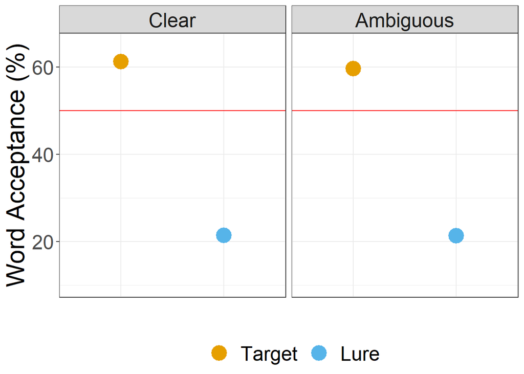

### Role of Phonological Awareness, with control variables Ravens IQ, Working Memory, and German CLT

```
## Generalized linear mixed model fit by maximum likelihood (Laplace
##   Approximation) [glmerMod]
##  Family: binomial  ( logit )
## Formula:
## detection ~ 1 + Word_Status * Boundary_Type * Phoneme_Manipulation.c +
##     RAVENS_IQ + Ger_CLT_Prod.c + WM_BackDigitSpan.c + (1 | subject_nr) +
##     (1 | Sentence_Num)
##    Data: Pseg_Htest
## Control: glmerControl(optimizer = "bobyqa")
##
##      AIC      BIC   logLik deviance df.resid
##   8471.0   8561.3  -4222.5   8445.0     7649
##
## Scaled residuals:
##     Min      1Q  Median      3Q     Max
## -5.7888 -0.6078 -0.3317  0.6951  5.0937
##
## Random effects:
##  Groups       Name        Variance Std.Dev.
##  Sentence_Num (Intercept) 0.1184   0.3441
##  subject_nr   (Intercept) 0.6280   0.7925
## Number of obs: 7662, groups:  Sentence_Num, 120; subject_nr, 102
##
## Fixed effects:
##                                                     Estimate Std. Error z value
## (Intercept)                                         1.130708   0.766419   1.475
## Word_Status1                                        1.973502   0.057694  34.207
## Boundary_Type1                                      0.025302   0.055409   0.457
## Phoneme_Manipulation.c                              0.014978   0.028247   0.530
## RAVENS_IQ                                          -0.016010   0.007521  -2.129
## Ger_CLT_Prod.c                                     -0.057240   0.045003  -1.272
## WM_BackDigitSpan.c                                 -0.129870   0.108407  -1.198
## Word_Status1:Boundary_Type1                         0.055179   0.110650   0.499
## Word_Status1:Phoneme_Manipulation.c                 0.147066   0.018182   8.089
## Boundary_Type1:Phoneme_Manipulation.c              -0.009462   0.017690  -0.535
## Word_Status1:Boundary_Type1:Phoneme_Manipulation.c  0.040520   0.035526   1.141
##                                                    Pr(>|z|)
## (Intercept)                                          0.1401
## Word_Status1                                        < 2e-16 ***
## Boundary_Type1                                       0.6479
```

[output cut: 23 more lines]

```
##             B_T1:P
## Word_Stats1
## Bondry_Typ1
## Phnm_Mnplt.
## RAVENS_IQ
## Gr_CLT_Prd.
## WM_BckDgtS.
## Wrd_S1:B_T1
## Wrd_S1:P_M.
## Bnd_T1:P_M.
## W_S1:B_T1:P -0.219
## optimizer (bobyqa) convergence code: 1 (bobyqa -- maximum number of function evaluations exceeded)
## Model failed to converge with max|grad| = 0.0128594 (tol = 0.002, component 1)
## Model is nearly unidentifiable: very large eigenvalue
##  - Rescale variables?
```

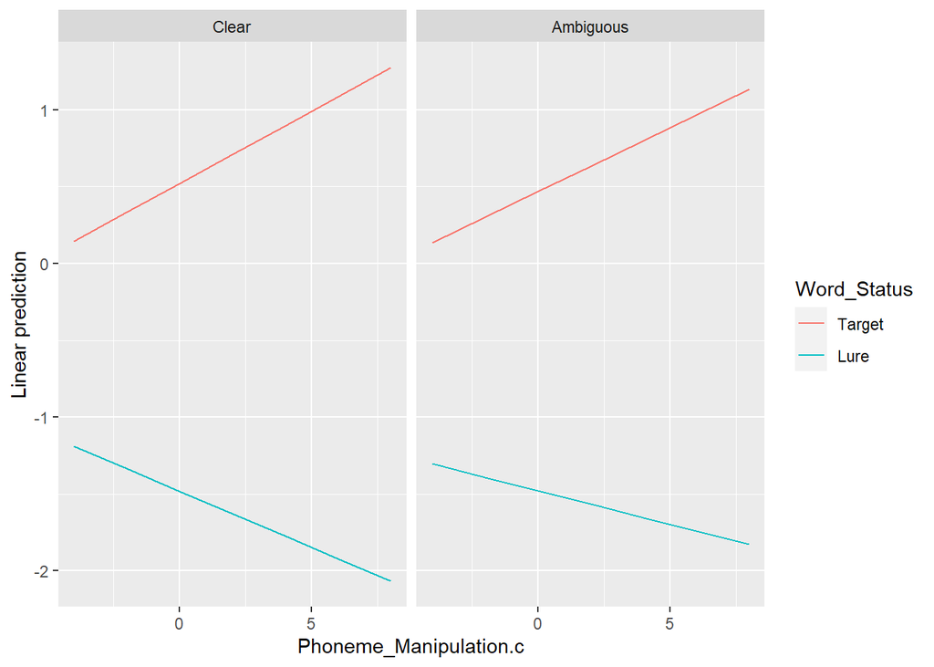

### *d’* analyses

```
## Linear mixed model fit by REML. t-tests use Satterthwaite's method [
## lmerModLmerTest]
## Formula: dprime ~ 1 + Boundary_Type + Phoneme_Manipulation.c + RAVENS_IQ +
##     Ger_CLT_Prod.c + WM_BackDigitSpan.c + (1 | subject_nr)
##    Data: d_calc
##
## REML criterion at convergence: 477.2
##
## Scaled residuals:
##      Min       1Q   Median       3Q      Max
## -2.65993 -0.52692  0.00436  0.54149  1.86272
##
## Random effects:
##  Groups     Name        Variance Std.Dev.
##  subject_nr (Intercept) 0.4556   0.6750
##  Residual               0.2548   0.5048
## Number of obs: 204, groups:  subject_nr, 102
##
## Fixed effects:
##                          Estimate Std. Error         df t value Pr(>|t|)
## (Intercept)             -0.416619   0.695470  97.000006  -0.599   0.5505
## Boundary_Type1           0.061481   0.070686 101.000001   0.870   0.3865
## Phoneme_Manipulation.c   0.038349   0.025478  96.999998   1.505   0.1355
## RAVENS_IQ                0.015803   0.006828  97.000006   2.314   0.0228 *
## Ger_CLT_Prod.c           0.056987   0.040941  96.999998   1.392   0.1671
## WM_BackDigitSpan.c       0.215238   0.098116  96.999998   2.194   0.0306 *
## ---
## Signif. codes:  0 '***' 0.001 '**' 0.01 '*' 0.05 '.' 0.1 ' ' 1
##
## Correlation of Fixed Effects:
##             (Intr) Bnd_T1 Phn_M. RAVENS G_CLT_
## Bondry_Typ1  0.000
## Phnm_Mnplt.  0.124  0.000
## RAVENS_IQ   -0.994  0.000 -0.123
## Gr_CLT_Prd. -0.073  0.000 -0.118  0.074
## WM_BckDgtS.  0.084  0.000 -0.323 -0.085 -0.300
```

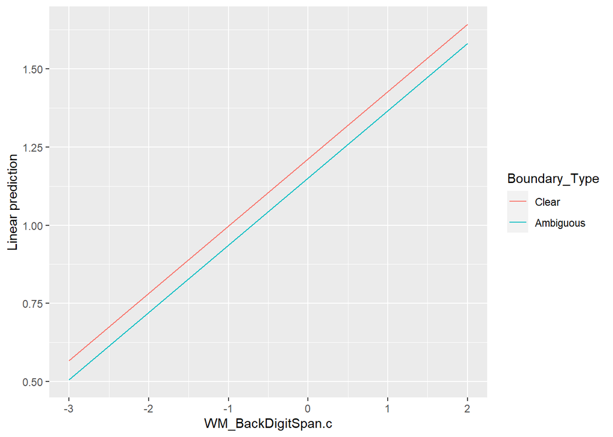

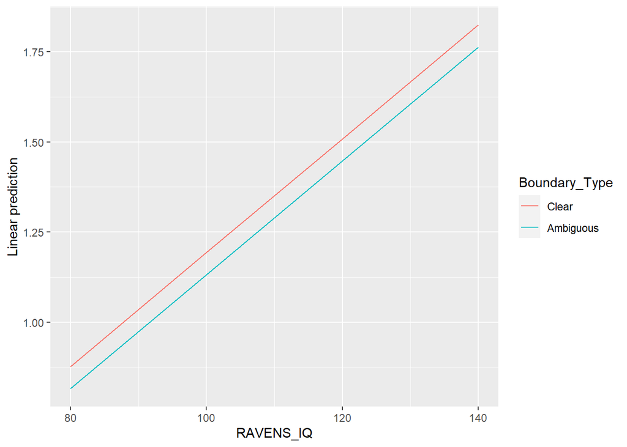

## Experiment Task Variables

### Trial by Word Status by Boundary Type

```
## Generalized linear mixed model fit by maximum likelihood (Laplace
##   Approximation) [glmerMod]
##  Family: binomial  ( logit )
## Formula: detection ~ 1 + Word_Status * Boundary_Type * Trial.c + (1 |
##     subject_nr) + (1 | Sentence_Num)
##    Data: Pseg_Htest
## Control: glmerControl(optimizer = "bobyqa")
##
##      AIC      BIC   logLik deviance df.resid
##   8824.7   8894.5  -4402.3   8804.7     7957
##
## Scaled residuals:
##     Min      1Q  Median      3Q     Max
## -6.6107 -0.6050 -0.3357  0.7066  5.9650
##
## Random effects:
##  Groups       Name        Variance Std.Dev.
##  Sentence_Num (Intercept) 0.1128   0.3359
##  subject_nr   (Intercept) 0.7239   0.8508
## Number of obs: 7967, groups:  Sentence_Num, 120; subject_nr, 106
##
## Fixed effects:
##                                       Estimate Std. Error z value Pr(>|z|)
## (Intercept)                         -0.5070061  0.0924212  -5.486 4.12e-08 ***
## Word_Status1                         1.9809687  0.0564324  35.103  < 2e-16 ***
## Boundary_Type1                       0.0476985  0.0540002   0.883  0.37707
## Trial.c                              0.0013656  0.0007837   1.743  0.08142 .
## Word_Status1:Boundary_Type1          0.0519388  0.1078777   0.481  0.63019
## Word_Status1:Trial.c                -0.0051628  0.0015713  -3.286  0.00102 **
## Boundary_Type1:Trial.c              -0.0022947  0.0015715  -1.460  0.14423
## Word_Status1:Boundary_Type1:Trial.c  0.0056720  0.0031407   1.806  0.07092 .
## ---
## Signif. codes:  0 '***' 0.001 '**' 0.01 '*' 0.05 '.' 0.1 ' ' 1
##
## Correlation of Fixed Effects:
##             (Intr) Wrd_S1 Bnd_T1 Tril.c Wr_S1:B_T1 W_S1:T B_T1:T
## Word_Stats1 -0.059
## Bondry_Typ1  0.000  0.009
## Trial.c     -0.011  0.028  0.006
## Wrd_S1:B_T1  0.001  0.003 -0.161 -0.019
## Wrd_Stt1:T.  0.009 -0.044 -0.020 -0.169  0.007
## Bndry_T1:T.  0.002 -0.018 -0.036 -0.001  0.024      0.015
## W_S1:B_T1:T -0.006  0.009  0.025  0.011 -0.038     -0.002 -0.171
## optimizer (bobyqa) convergence code: 0 (OK)
## Model is nearly unidentifiable: very large eigenvalue
##  - Rescale variables?
```

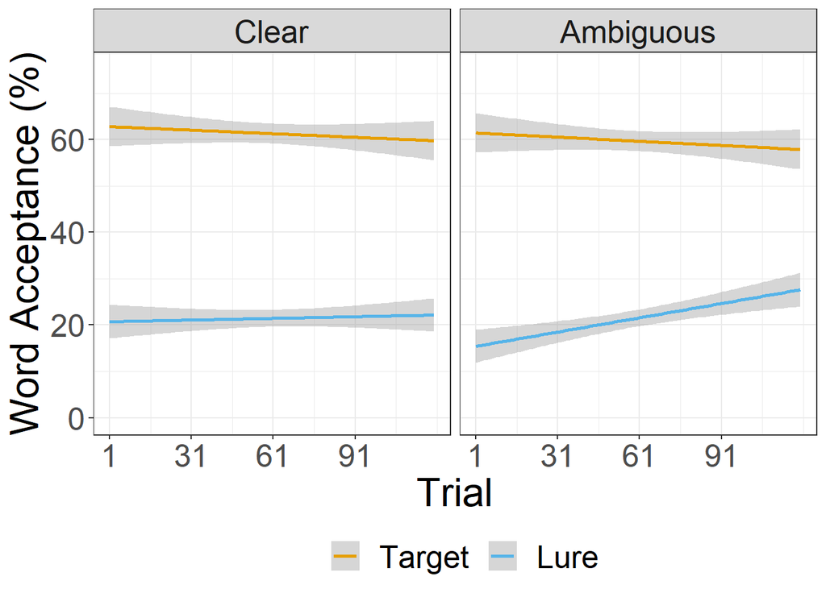

### Counterbalance List by Word Candidate Length by Boundary Type

```
## # A tibble: 6 × 2
##   List  total_participants
##   <fct>              <int>
## 1 A                     21
## 2 B                     18
## 3 C                     18
## 4 D                     16
## 5 E                     16
## 6 F                     17
```

```
## Generalized linear mixed model fit by maximum likelihood (Laplace
##   Approximation) [glmerMod]
##  Family: binomial  ( logit )
## Formula:
## detection ~ 1 + Word_Status * Boundary_Type * List + (1 | subject_nr) +
##     (1 | Sentence_Num)
##    Data: Pseg_Htest
## Control: glmerControl(optimizer = "bobyqa")
##
##      AIC      BIC   logLik deviance df.resid
##   8841.9   9023.5  -4395.0   8789.9     7941
##
## Scaled residuals:
##     Min      1Q  Median      3Q     Max
## -6.3042 -0.6095 -0.3386  0.7060  5.4473
##
## Random effects:
##  Groups       Name        Variance Std.Dev.
##  Sentence_Num (Intercept) 0.09803  0.3131
##  subject_nr   (Intercept) 0.68851  0.8298
## Number of obs: 7967, groups:  Sentence_Num, 120; subject_nr, 106
##
## Fixed effects:
##                                   Estimate Std. Error z value Pr(>|z|)
## (Intercept)                       -0.61852    0.19548  -3.164  0.00156 **
## Word_Status1                       2.17896    0.14940  14.585  < 2e-16 ***
## Boundary_Type1                    -0.07324    0.14507  -0.505  0.61367
## ListB                             -0.20968    0.28445  -0.737  0.46104
## ListC                              0.45102    0.28344   1.591  0.11156
## ListD                              0.17916    0.29310   0.611  0.54101
## ListE                              0.11974    0.29361   0.408  0.68341
## ListF                              0.15540    0.28777   0.540  0.58919
## Word_Status1:Boundary_Type1        0.49938    0.29006   1.722  0.08513 .
## Word_Status1:ListB                -0.17086    0.20905  -0.817  0.41373
## Word_Status1:ListC                -0.40048    0.21957  -1.824  0.06816 .
## Word_Status1:ListD                -0.44547    0.22548  -1.976  0.04819 *
## Word_Status1:ListE                -0.08765    0.22863  -0.383  0.70145
## Word_Status1:ListF                -0.07935    0.21015  -0.378  0.70572
## Boundary_Type1:ListB               0.13355    0.22724   0.588  0.55672
## Boundary_Type1:ListC               0.28732    0.19122   1.503  0.13296
## Boundary_Type1:ListD               0.08617    0.22131   0.389  0.69702
## Boundary_Type1:ListE              -0.09580    0.20170  -0.475  0.63482
## Boundary_Type1:ListF               0.26797    0.22735   1.179  0.23853
## Word_Status1:Boundary_Type1:ListB -0.81261    0.43233  -1.880  0.06016 .
## Word_Status1:Boundary_Type1:ListC -0.31059    0.43043  -0.722  0.47056
## Word_Status1:Boundary_Type1:ListD -0.84208    0.39599  -2.127  0.03346 *
## Word_Status1:Boundary_Type1:ListE -0.99410    0.44900  -2.214  0.02683 *
## Word_Status1:Boundary_Type1:ListF  0.28653    0.43263   0.662  0.50778
## ---
## Signif. codes:  0 '***' 0.001 '**' 0.01 '*' 0.05 '.' 0.1 ' ' 1
```

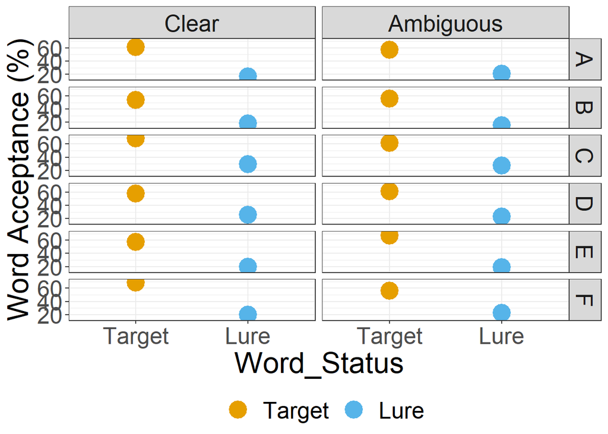

### Word Length (monosyllabic, bisyllabic)

```
## Generalized linear mixed model fit by maximum likelihood (Laplace
##   Approximation) [glmerMod]
##  Family: binomial  ( logit )
## Formula:
## detection ~ 1 + Word_Status * Boundary_Type * sylls + (1 | subject_nr) +
##     (1 | Sentence_Num)
##    Data: Pseg_Htest
## Control: glmerControl(optimizer = "bobyqa")
##
##      AIC      BIC   logLik deviance df.resid
##   8832.2   8902.0  -4406.1   8812.2     7957
##
## Scaled residuals:
##     Min      1Q  Median      3Q     Max
## -6.7972 -0.6064 -0.3422  0.7052  5.4635
##
## Random effects:
##  Groups       Name        Variance Std.Dev.
##  Sentence_Num (Intercept) 0.1023   0.3198
##  subject_nr   (Intercept) 0.7222   0.8498
## Number of obs: 7967, groups:  Sentence_Num, 120; subject_nr, 106
##
## Fixed effects:
##                                    Estimate Std. Error z value Pr(>|z|)
## (Intercept)                        -0.50475    0.09184  -5.496 3.89e-08 ***
## Word_Status1                        1.97675    0.05630  35.113  < 2e-16 ***
## Boundary_Type1                      0.04269    0.05390   0.792   0.4283
## sylls1                             -0.18285    0.07948  -2.301   0.0214 *
## Word_Status1:Boundary_Type1         0.05490    0.10768   0.510   0.6101
## Word_Status1:sylls1                -0.04282    0.10793  -0.397   0.6915
## Boundary_Type1:sylls1               0.06881    0.10779   0.638   0.5232
## Word_Status1:Boundary_Type1:sylls1  0.36100    0.21532   1.677   0.0936 .
## ---
## Signif. codes:  0 '***' 0.001 '**' 0.01 '*' 0.05 '.' 0.1 ' ' 1
##
## Correlation of Fixed Effects:
##             (Intr) Wrd_S1 Bnd_T1 sylls1 Wr_S1:B_T1 W_S1:1 B_T1:1
## Word_Stats1 -0.058
## Bondry_Typ1  0.001  0.003
## sylls1       0.003 -0.024  0.007
## Wrd_S1:B_T1  0.000  0.006 -0.158 -0.005
## Wrd_Stts1:1 -0.008  0.008 -0.007 -0.108  0.011
## Bndry_Ty1:1  0.003 -0.005  0.010  0.004 -0.030      0.000
## W_S1:B_T1:1 -0.002  0.013 -0.030 -0.001  0.010      0.006 -0.158
```

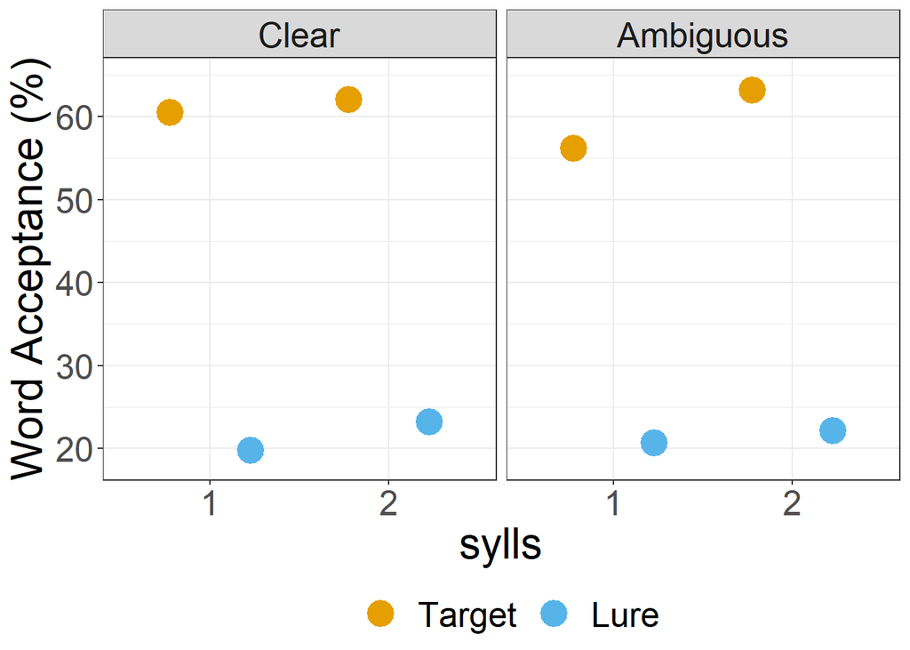

### Onset Boundary Context (sibilant, nonsibilant)

```
## Generalized linear mixed model fit by maximum likelihood (Laplace
##   Approximation) [glmerMod]
##  Family: binomial  ( logit )
## Formula: detection ~ 1 + Word_Status * Boundary_Type * Context1 + (1 |
##     subject_nr) + (1 | Sentence_Num)
##    Data: Pseg_Htest
## Control: glmerControl(optimizer = "bobyqa")
##
##      AIC      BIC   logLik deviance df.resid
##   8837.9   8907.7  -4409.0   8817.9     7957
##
## Scaled residuals:
##     Min      1Q  Median      3Q     Max
## -6.7317 -0.6080 -0.3419  0.7077  5.5011
##
## Random effects:
##  Groups       Name        Variance Std.Dev.
##  Sentence_Num (Intercept) 0.1104   0.3323
##  subject_nr   (Intercept) 0.7232   0.8504
## Number of obs: 7967, groups:  Sentence_Num, 120; subject_nr, 106
##
## Fixed effects:
##                                       Estimate Std. Error z value Pr(>|z|)
## (Intercept)                           -0.50517    0.09226  -5.475 4.37e-08 ***
## Word_Status1                           1.97753    0.05631  35.120  < 2e-16 ***
## Boundary_Type1                         0.04454    0.05388   0.827    0.408
## Context11                              0.05797    0.08115   0.714    0.475
## Word_Status1:Boundary_Type1            0.05379    0.10764   0.500    0.617
## Word_Status1:Context11                 0.10200    0.10797   0.945    0.345
## Boundary_Type1:Context11              -0.14235    0.10775  -1.321    0.186
## Word_Status1:Boundary_Type1:Context11 -0.05526    0.21526  -0.257    0.797
## ---
## Signif. codes:  0 '***' 0.001 '**' 0.01 '*' 0.05 '.' 0.1 ' ' 1
##
## Correlation of Fixed Effects:
##             (Intr) Wrd_S1 Bnd_T1 Cntx11 Wr_S1:B_T1 W_S1:C B_T1:C
## Word_Stats1 -0.058
## Bondry_Typ1  0.001  0.005
## Context11    0.000  0.007  0.006
## Wrd_S1:B_T1  0.000  0.005 -0.158 -0.009
## Wrd_St1:C11  0.002  0.010 -0.012 -0.106  0.009
## Bndr_T1:C11  0.003 -0.014  0.004  0.003  0.010      0.002
## W_S1:B_T1:C -0.003  0.008  0.010  0.001  0.004      0.005 -0.158
```

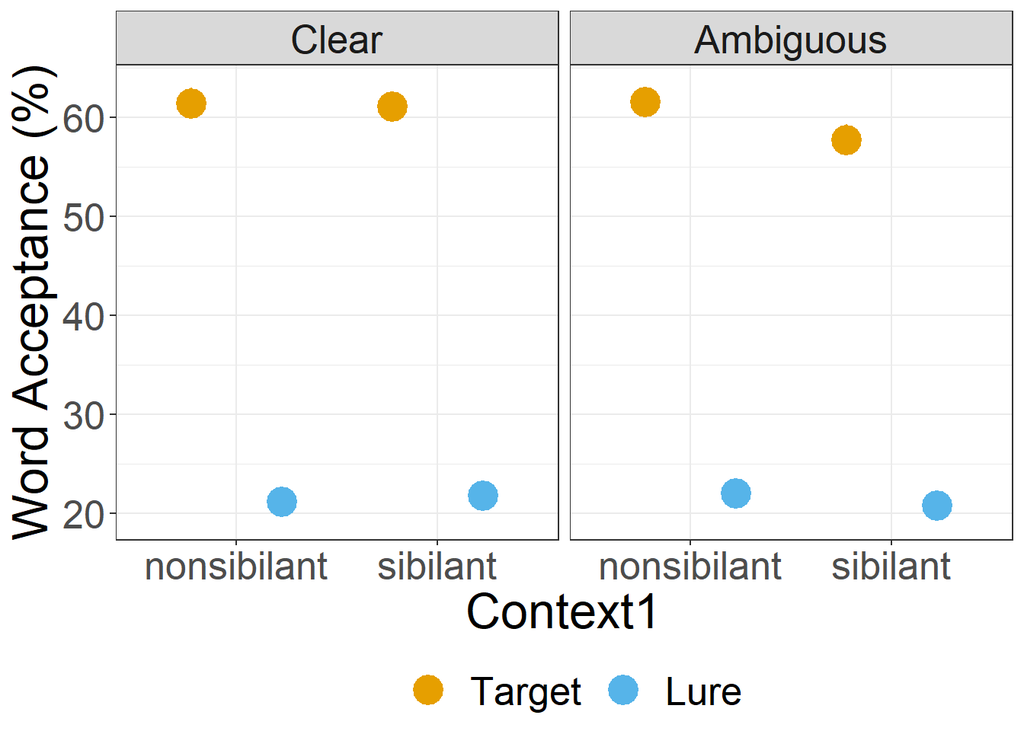

### Coda Boundary Context (liquid, stop, vowel, fricative)

```
## Generalized linear mixed model fit by maximum likelihood (Laplace
##   Approximation) [glmerMod]
##  Family: binomial  ( logit )
## Formula: detection ~ 1 + Word_Status * Boundary_Type * Context2 + (1 |
##     subject_nr) + (1 | Sentence_Num)
##    Data: Pseg_Htest
## Control: glmerControl(optimizer = "bobyqa")
##
##      AIC      BIC   logLik deviance df.resid
##   8850.0   8975.7  -4407.0   8814.0     7949
##
## Scaled residuals:
##     Min      1Q  Median      3Q     Max
## -6.3620 -0.6064 -0.3399  0.7063  5.3941
##
## Random effects:
##  Groups       Name        Variance Std.Dev.
##  Sentence_Num (Intercept) 0.1114   0.3337
##  subject_nr   (Intercept) 0.7215   0.8494
## Number of obs: 7967, groups:  Sentence_Num, 120; subject_nr, 106
##
## Fixed effects:
##                                        Estimate Std. Error z value Pr(>|z|)
## (Intercept)                           -0.523401   0.101084  -5.178 2.24e-07 ***
## Word_Status1                           2.083355   0.079745  26.125  < 2e-16 ***
## Boundary_Type1                         0.003108   0.078176   0.040   0.9683
## Context22                              0.037279   0.083723   0.445   0.6561
## Context23                             -0.063594   0.228828  -0.278   0.7811
## Context24                              0.190748   0.323513   0.590   0.5554
## Word_Status1:Boundary_Type1            0.069945   0.155496   0.450   0.6528
## Word_Status1:Context22                -0.208281   0.112191  -1.856   0.0634 .
## Word_Status1:Context23                -0.326776   0.303118  -1.078   0.2810
## Word_Status1:Context24                 0.091425   0.435335   0.210   0.8337
## Boundary_Type1:Context22               0.098094   0.113122   0.867   0.3859
## Boundary_Type1:Context23               0.009036   0.302887   0.030   0.9762
## Boundary_Type1:Context24              -0.224996   0.436222  -0.516   0.6060
## Word_Status1:Boundary_Type1:Context22 -0.094717   0.223536  -0.424   0.6718
## Word_Status1:Boundary_Type1:Context23  0.445489   0.602168   0.740   0.4594
## Word_Status1:Boundary_Type1:Context24  0.684321   0.869438   0.787   0.4312
## ---
## Signif. codes:  0 '***' 0.001 '**' 0.01 '*' 0.05 '.' 0.1 ' ' 1
```

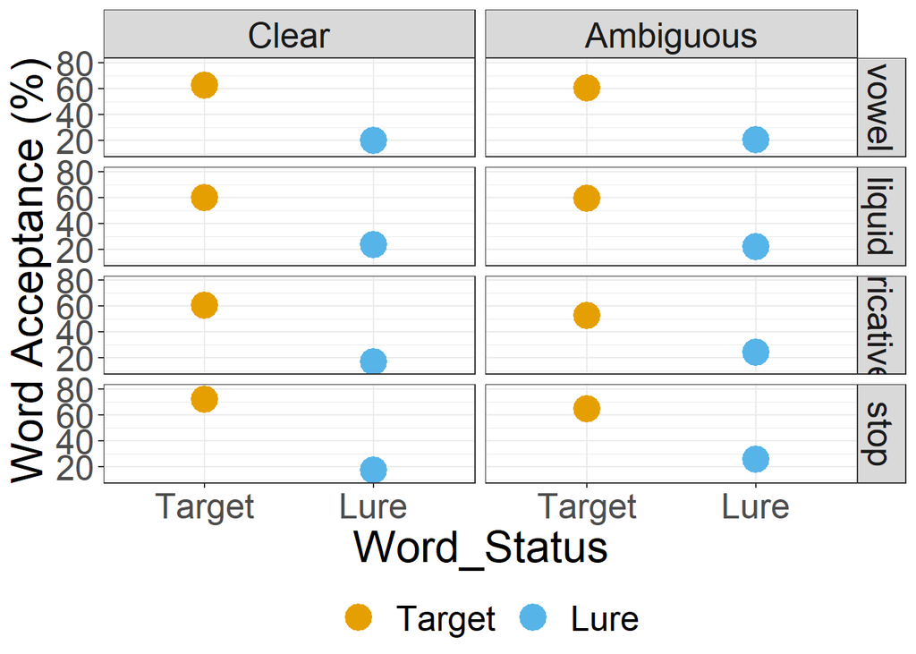

## Participant Variables: Predictors

### Correlation Individual Differences

Take with a grain of salt, these scores are the “grob” ones coded during the experiment and for some participants there are missing values (for unsure codes), but this should be fairly close to what the final coded values will be.

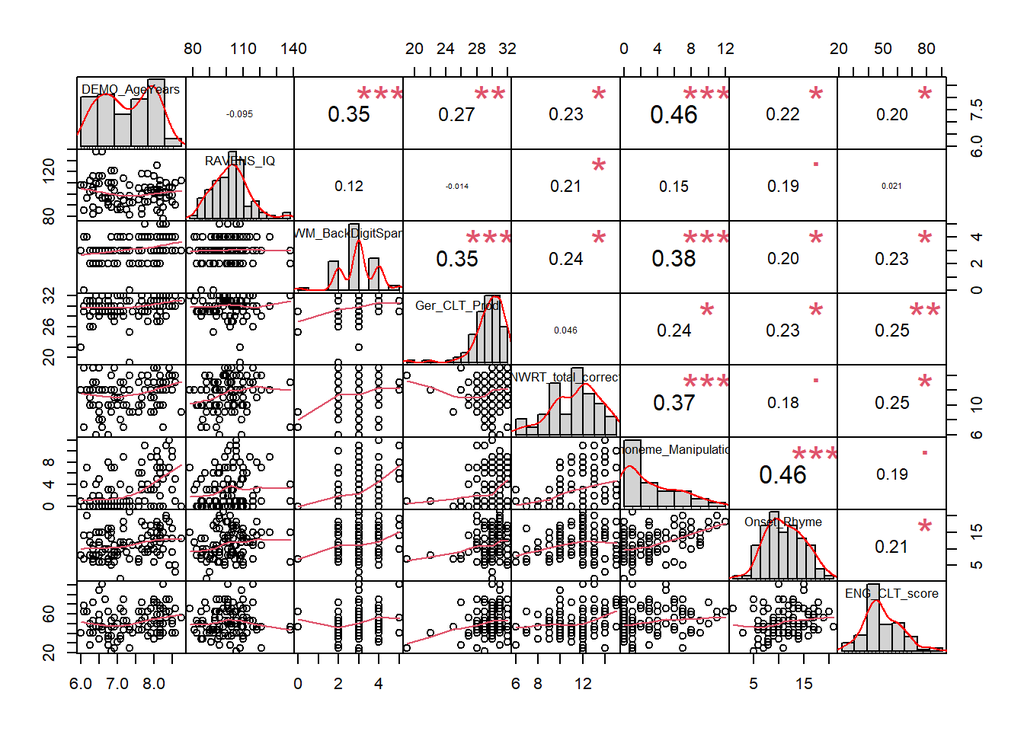

### Phonological Awareness by Word Candidate Length by Boundary Type

#### Phoneme Manipulation task score

```
## Generalized linear mixed model fit by maximum likelihood (Laplace
##   Approximation) [glmerMod]
##  Family: binomial  ( logit )
## Formula:
## detection ~ 1 + Word_Status * Boundary_Type * Phoneme_Manipulation.c +
##     (1 | subject_nr) + (1 | Sentence_Num)
##    Data: Pseg_Htest
## Control: glmerControl(optimizer = "bobyqa")
##
##      AIC      BIC   logLik deviance df.resid
##   8678.9   8748.6  -4329.5   8658.9     7879
##
## Scaled residuals:
##     Min      1Q  Median      3Q     Max
## -5.5532 -0.6073 -0.3273  0.6873  5.2825
##
## Random effects:
##  Groups       Name        Variance Std.Dev.
##  Sentence_Num (Intercept) 0.1180   0.3435
##  subject_nr   (Intercept) 0.7023   0.8380
## Number of obs: 7889, groups:  Sentence_Num, 120; subject_nr, 105
##
## Fixed effects:
##                                                    Estimate Std. Error z value
## (Intercept)                                        -0.51237    0.09202  -5.568
## Word_Status1                                        1.99017    0.05714  34.827
## Boundary_Type1                                      0.03247    0.05482   0.592
## Phoneme_Manipulation.c                             -0.01441    0.02685  -0.537
## Word_Status1:Boundary_Type1                         0.07863    0.10947   0.718
## Word_Status1:Phoneme_Manipulation.c                 0.15330    0.01820   8.422
## Boundary_Type1:Phoneme_Manipulation.c              -0.01073    0.01768  -0.607
## Word_Status1:Boundary_Type1:Phoneme_Manipulation.c  0.04384    0.03552   1.234
##                                                    Pr(>|z|)
## (Intercept)                                        2.58e-08 ***
## Word_Status1                                        < 2e-16 ***
## Boundary_Type1                                        0.554
## Phoneme_Manipulation.c                                0.591
## Word_Status1:Boundary_Type1                           0.473
## Word_Status1:Phoneme_Manipulation.c                 < 2e-16 ***
## Boundary_Type1:Phoneme_Manipulation.c                 0.544
## Word_Status1:Boundary_Type1:Phoneme_Manipulation.c    0.217
## ---
## Signif. codes:  0 '***' 0.001 '**' 0.01 '*' 0.05 '.' 0.1 ' ' 1
##
## Correlation of Fixed Effects:
##             (Intr) Wrd_S1 Bnd_T1 Phn_M. Wr_S1:B_T1 W_S1:P B_T1:P
## Word_Stats1 -0.063
## Bondry_Typ1  0.004 -0.004
## Phnm_Mnplt.  0.009 -0.025  0.008
## Wrd_S1:B_T1 -0.002  0.015 -0.171 -0.007
## Wrd_S1:P_M. -0.026  0.102 -0.017 -0.080  0.021
## Bnd_T1:P_M.  0.007 -0.019  0.088  0.014 -0.078     -0.027
## W_S1:B_T1:P -0.007  0.028 -0.078 -0.006  0.088      0.041 -0.222
```

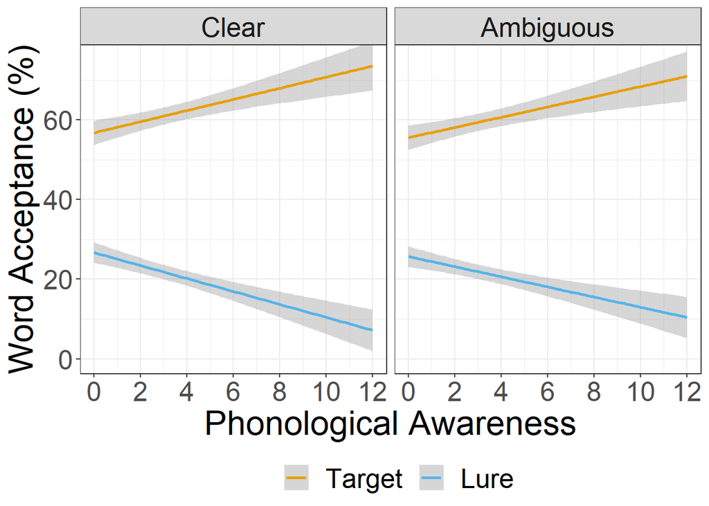

#### Onset/Rhyme Score

```
## Generalized linear mixed model fit by maximum likelihood (Laplace
##   Approximation) [glmerMod]
##  Family: binomial  ( logit )
## Formula: detection ~ 1 + Word_Status * Boundary_Type * Onset_Rhyme.c +
##     (1 | subject_nr) + (1 | Sentence_Num)
##    Data: Pseg_Htest
## Control: glmerControl(optimizer = "bobyqa")
##
##      AIC      BIC   logLik deviance df.resid
##   8567.3   8637.0  -4273.7   8547.3     7807
##
## Scaled residuals:
##     Min      1Q  Median      3Q     Max
## -5.2334 -0.6110 -0.3142  0.6912  7.0368
##
## Random effects:
##  Groups       Name        Variance Std.Dev.
##  Sentence_Num (Intercept) 0.1146   0.3386
##  subject_nr   (Intercept) 0.6978   0.8353
## Number of obs: 7817, groups:  Sentence_Num, 120; subject_nr, 104
##
## Fixed effects:
##                                           Estimate Std. Error z value Pr(>|z|)
## (Intercept)                               -0.53003    0.09213  -5.753 8.78e-09
## Word_Status1                               2.00934    0.05807  34.600  < 2e-16
## Boundary_Type1                             0.02054    0.05572   0.369   0.7124
## Onset_Rhyme.c                             -0.04966    0.02112  -2.351   0.0187
## Word_Status1:Boundary_Type1                0.09433    0.11130   0.847   0.3967
## Word_Status1:Onset_Rhyme.c                 0.14282    0.01395  10.237  < 2e-16
## Boundary_Type1:Onset_Rhyme.c              -0.02389    0.01359  -1.758   0.0787
## Word_Status1:Boundary_Type1:Onset_Rhyme.c  0.03041    0.02716   1.120   0.2629
##
## (Intercept)                               ***
## Word_Status1                              ***
## Boundary_Type1
## Onset_Rhyme.c                             *
## Word_Status1:Boundary_Type1
## Word_Status1:Onset_Rhyme.c                ***
## Boundary_Type1:Onset_Rhyme.c              .
## Word_Status1:Boundary_Type1:Onset_Rhyme.c
## ---
## Signif. codes:  0 '***' 0.001 '**' 0.01 '*' 0.05 '.' 0.1 ' ' 1
##
## Correlation of Fixed Effects:
##             (Intr) Wrd_S1 Bnd_T1 Ons_R. Wr_S1:B_T1 W_S1:O B_T1:O
## Word_Stats1 -0.072
## Bondry_Typ1  0.007 -0.015
## Onst_Rhym.c  0.016 -0.046  0.010
## Wrd_S1:B_T1 -0.006  0.023 -0.195 -0.009
## Wrd_S1:O_R. -0.044  0.153 -0.029 -0.072  0.031
## Bnd_T1:O_R.  0.010 -0.029  0.136  0.010 -0.125     -0.023
## W_S1:B_T1:O -0.008  0.030 -0.125 -0.008  0.136      0.030 -0.199
```

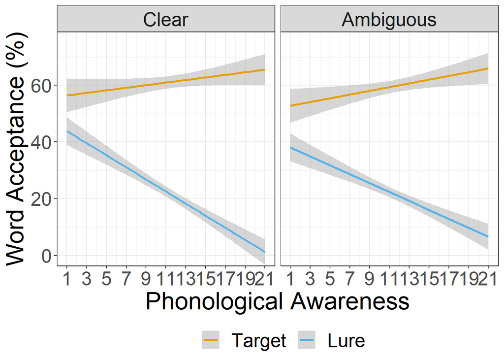

### Grade

Approximation for now for L1 knowledge

```
## Generalized linear mixed model fit by maximum likelihood (Laplace
##   Approximation) [glmerMod]
##  Family: binomial  ( logit )
## Formula: detection ~ 1 + Word_Status * Boundary_Type * DEMO_SchoolGrade +
##     (1 | subject_nr) + (1 | Sentence_Num)
##    Data: Pseg_Htest
## Control: glmerControl(optimizer = "bobyqa")
##
##      AIC      BIC   logLik deviance df.resid
##   8727.1   8797.0  -4353.6   8707.1     7957
##
## Scaled residuals:
##     Min      1Q  Median      3Q     Max
## -5.4306 -0.6027 -0.3089  0.6981  6.6366
##
## Random effects:
##  Groups       Name        Variance Std.Dev.
##  Sentence_Num (Intercept) 0.1178   0.3432
##  subject_nr   (Intercept) 0.7035   0.8387
## Number of obs: 7967, groups:  Sentence_Num, 120; subject_nr, 106
##
## Fixed effects:
##                                               Estimate Std. Error z value
## (Intercept)                                   -0.52735    0.09183  -5.743
## Word_Status1                                   2.03213    0.05779  35.165
## Boundary_Type1                                 0.03461    0.05517   0.627
## DEMO_SchoolGrade1                              0.20232    0.17248   1.173
## Word_Status1:Boundary_Type1                    0.08765    0.11025   0.795
## Word_Status1:DEMO_SchoolGrade1                -1.18595    0.11382 -10.419
## Boundary_Type1:DEMO_SchoolGrade1               0.04926    0.11035   0.446
## Word_Status1:Boundary_Type1:DEMO_SchoolGrade1 -0.40113    0.22146  -1.811
##                                               Pr(>|z|)
## (Intercept)                                   9.31e-09 ***
## Word_Status1                                   < 2e-16 ***
## Boundary_Type1                                  0.5305
## DEMO_SchoolGrade1                               0.2408
## Word_Status1:Boundary_Type1                     0.4266
## Word_Status1:DEMO_SchoolGrade1                 < 2e-16 ***
## Boundary_Type1:DEMO_SchoolGrade1                0.6553
## Word_Status1:Boundary_Type1:DEMO_SchoolGrade1   0.0701 .
## ---
## Signif. codes:  0 '***' 0.001 '**' 0.01 '*' 0.05 '.' 0.1 ' ' 1
##
## Correlation of Fixed Effects:
##             (Intr) Wrd_S1 Bnd_T1 DEMO_S Wr_S1:B_T1 W_S1:D B_T1:D
## Word_Stats1 -0.069
## Bondry_Typ1  0.005 -0.006
## DEMO_SchlG1 -0.044  0.036 -0.009
## Wrd_S1:B_T1 -0.004  0.020 -0.190  0.006
## W_S1:DEMO_S  0.036 -0.175  0.015 -0.068 -0.028
## B_T1:DEMO_S -0.009  0.018 -0.146  0.006  0.110     -0.011
## W_S1:B_T1:D  0.007 -0.035  0.108 -0.003 -0.149      0.022 -0.191
```

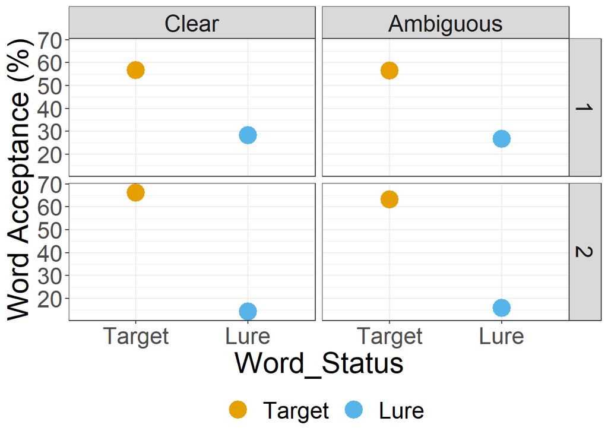

### Age

Approximation for now for L1 knowledge

```
## Generalized linear mixed model fit by maximum likelihood (Laplace
##   Approximation) [glmerMod]
##  Family: binomial  ( logit )
## Formula: detection ~ 1 + Word_Status * Boundary_Type * DEMO_AgeYears.c +
##     (1 | subject_nr) + (1 | Sentence_Num)
##    Data: Pseg_Htest
## Control: glmerControl(optimizer = "bobyqa")
##
##      AIC      BIC   logLik deviance df.resid
##   8552.4   8622.0  -4266.2   8532.4     7730
##
## Scaled residuals:
##     Min      1Q  Median      3Q     Max
## -6.3726 -0.6010 -0.3253  0.7018  6.2269
##
## Random effects:
##  Groups       Name        Variance Std.Dev.
##  Sentence_Num (Intercept) 0.1160   0.3405
##  subject_nr   (Intercept) 0.6971   0.8349
## Number of obs: 7740, groups:  Sentence_Num, 120; subject_nr, 103
##
## Fixed effects:
##                                             Estimate Std. Error z value
## (Intercept)                                 -0.49583    0.09241  -5.366
## Word_Status1                                 1.97932    0.05754  34.396
## Boundary_Type1                               0.03313    0.05513   0.601
## DEMO_AgeYears.c                             -0.08071    0.11408  -0.707
## Word_Status1:Boundary_Type1                  0.04443    0.11013   0.403
## Word_Status1:DEMO_AgeYears.c                 0.64853    0.07424   8.736
## Boundary_Type1:DEMO_AgeYears.c              -0.02511    0.07232  -0.347
## Word_Status1:Boundary_Type1:DEMO_AgeYears.c  0.17771    0.14525   1.223
##                                             Pr(>|z|)
## (Intercept)                                 8.07e-08 ***
## Word_Status1                                 < 2e-16 ***
## Boundary_Type1                                 0.548
## DEMO_AgeYears.c                                0.479
## Word_Status1:Boundary_Type1                    0.687
## Word_Status1:DEMO_AgeYears.c                 < 2e-16 ***
## Boundary_Type1:DEMO_AgeYears.c                 0.728
## Word_Status1:Boundary_Type1:DEMO_AgeYears.c    0.221
## ---
## Signif. codes:  0 '***' 0.001 '**' 0.01 '*' 0.05 '.' 0.1 ' ' 1
##
## Correlation of Fixed Effects:
##             (Intr) Wrd_S1 Bnd_T1 DEMO_A Wr_S1:B_T1 W_S1:D B_T1:D
## Word_Stats1 -0.062
## Bondry_Typ1  0.003  0.000
## DEMO_AgYrs.  0.013 -0.025  0.005
## Wrd_S1:B_T1 -0.001  0.011 -0.168 -0.004
## W_S1:DEMO_A -0.024  0.107 -0.008 -0.061  0.016
## B_T1:DEMO_A  0.005 -0.012  0.086  0.004 -0.079     -0.003
## W_S1:B_T1:D -0.005  0.023 -0.074  0.000  0.088      0.013 -0.175
```

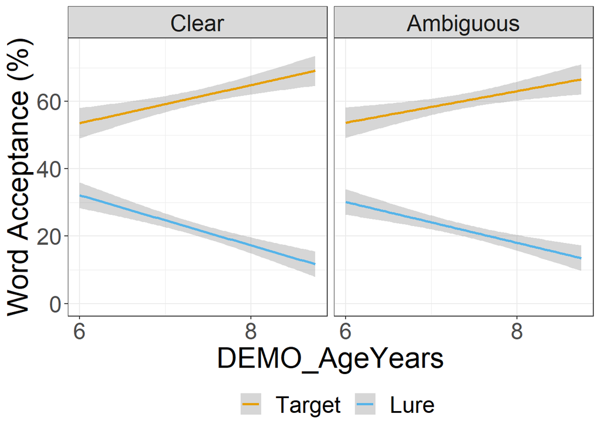

### German Production CLT

```
## Generalized linear mixed model fit by maximum likelihood (Laplace
##   Approximation) [glmerMod]
##  Family: binomial  ( logit )
## Formula: detection ~ 1 + Boundary_Type * Word_Status * Ger_CLT_Prod.c +
##     (1 | subject_nr) + (1 | Sentence_Num)
##    Data: Pseg_Htest
## Control: glmerControl(optimizer = "bobyqa")
##
##      AIC      BIC   logLik deviance df.resid
##   8793.0   8862.9  -4386.5   8773.0     7957
##
## Scaled residuals:
##     Min      1Q  Median      3Q     Max
## -4.7552 -0.6059 -0.3308  0.7104  5.6559
##
## Random effects:
##  Groups       Name        Variance Std.Dev.
##  Sentence_Num (Intercept) 0.1120   0.3347
##  subject_nr   (Intercept) 0.7132   0.8445
## Number of obs: 7967, groups:  Sentence_Num, 120; subject_nr, 106
##
## Fixed effects:
##                                            Estimate Std. Error z value Pr(>|z|)
## (Intercept)                                -0.51552    0.09189  -5.610 2.02e-08
## Boundary_Type1                              0.04248    0.05424   0.783   0.4335
## Word_Status1                                1.99646    0.05684  35.126  < 2e-16
## Ger_CLT_Prod.c                             -0.07329    0.04359  -1.681   0.0927
## Boundary_Type1:Word_Status1                 0.05979    0.10835   0.552   0.5811
## Boundary_Type1:Ger_CLT_Prod.c              -0.02489    0.02593  -0.960   0.3372
## Word_Status1:Ger_CLT_Prod.c                 0.18067    0.02663   6.785 1.16e-11
## Boundary_Type1:Word_Status1:Ger_CLT_Prod.c  0.01250    0.05187   0.241   0.8096
##
## (Intercept)                                ***
## Boundary_Type1
## Word_Status1                               ***
## Ger_CLT_Prod.c                             .
## Boundary_Type1:Word_Status1
## Boundary_Type1:Ger_CLT_Prod.c
## Word_Status1:Ger_CLT_Prod.c                ***
## Boundary_Type1:Word_Status1:Ger_CLT_Prod.c
## ---
## Signif. codes:  0 '***' 0.001 '**' 0.01 '*' 0.05 '.' 0.1 ' ' 1
##
## Correlation of Fixed Effects:
##             (Intr) Bnd_T1 Wrd_S1 G_CLT_ Bn_T1:W_S1 B_T1:G W_S1:G
## Bondry_Typ1  0.002
## Word_Stats1 -0.063  0.002
## Gr_CLT_Prd.  0.011  0.000 -0.022
## Bnd_T1:W_S1 -0.001 -0.169  0.008  0.000
## B_T1:G_CLT_  0.001  0.060 -0.002 -0.001 -0.051
## W_S1:G_CLT_ -0.020 -0.002  0.088 -0.028  0.001     -0.011
## B_T1:W_S1:G  0.001 -0.049  0.002 -0.003  0.062     -0.072 -0.006
```

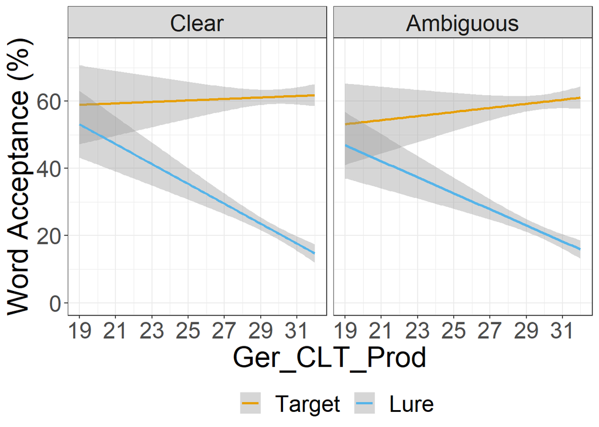

## Participant Variables: Exploratory

### Language Background (Monolingual, Bilingual)

```
## # A tibble: 2 × 2
##   LANG_Bilingual total_participants
##   <fct>                       <int>
## 1 monolingual                    77
## 2 bilingual                      29
```

```
## # A tibble: 1 × 8
##   .y.           group1      group2       n1    n2 statistic    df      p
## * <chr>         <chr>       <chr>     <int> <int>     <dbl> <dbl>  <dbl>
## 1 DEMO_AgeYears monolingual bilingual    75    28      2.01  52.7 0.0497
```

```
## # A tibble: 1 × 8
##   .y.       group1      group2       n1    n2 statistic    df     p
## * <chr>     <chr>       <chr>     <int> <int>     <dbl> <dbl> <dbl>
## 1 RAVENS_IQ monolingual bilingual    75    28    -0.976  49.3 0.334
```

```
## # A tibble: 1 × 8
##   .y.              group1      group2       n1    n2 statistic    df     p
## * <chr>            <chr>       <chr>     <int> <int>     <dbl> <dbl> <dbl>
## 1 WM_BackDigitSpan monolingual bilingual    77    29     0.470  42.9  0.64
```

```
## # A tibble: 1 × 8
##   .y.          group1      group2       n1    n2 statistic    df      p
## * <chr>        <chr>       <chr>     <int> <int>     <dbl> <dbl>  <dbl>
## 1 Ger_CLT_Prod monolingual bilingual    77    29      2.48  34.0 0.0184
```

```
## # A tibble: 1 × 8
##   .y.                group1      group2       n1    n2 statistic    df     p
## * <chr>              <chr>       <chr>     <int> <int>     <dbl> <dbl> <dbl>
## 1 NWRT_total_correct monolingual bilingual    77    29     -1.61  48.3 0.113
```

```
## # A tibble: 1 × 8
##   .y.                  group1      group2       n1    n2 statistic    df     p
## * <chr>                <chr>       <chr>     <int> <int>     <dbl> <dbl> <dbl>
## 1 Phoneme_Manipulation monolingual bilingual    76    29      1.40  53.5 0.168
```

```
## # A tibble: 1 × 8
##   .y.         group1      group2       n1    n2 statistic    df     p
## * <chr>       <chr>       <chr>     <int> <int>     <dbl> <dbl> <dbl>
## 1 Onset_Rhyme monolingual bilingual    76    28    -0.787  56.7 0.434
```

```
## # A tibble: 1 × 8
##   .y.           group1      group2       n1    n2 statistic    df       p
## * <chr>         <chr>       <chr>     <int> <int>     <dbl> <dbl>   <dbl>
## 1 ENG_CLT_score monolingual bilingual    76    29     -2.74  42.0 0.00897
```

```
## Generalized linear mixed model fit by maximum likelihood (Laplace
##   Approximation) [glmerMod]
##  Family: binomial  ( logit )
## Formula: detection ~ 1 + Boundary_Type * Word_Status * LANG_Bilingual +
##     (1 | subject_nr) + (1 | Sentence_Num)
##    Data: Pseg_Htest
## Control: glmerControl(optimizer = "bobyqa")
##
##      AIC      BIC   logLik deviance df.resid
##   8837.3   8907.2  -4408.7   8817.3     7957
##
## Scaled residuals:
##     Min      1Q  Median      3Q     Max
## -6.1180 -0.6084 -0.3414  0.7070  5.5207
##
## Random effects:
##  Groups       Name        Variance Std.Dev.
##  Sentence_Num (Intercept) 0.1109   0.3331
##  subject_nr   (Intercept) 0.7180   0.8474
## Number of obs: 7967, groups:  Sentence_Num, 120; subject_nr, 106
##
## Fixed effects:
##                                              Estimate Std. Error z value
## (Intercept)                                 -0.524540   0.102265  -5.129
## Boundary_Type1                               0.082393   0.060722   1.357
## Word_Status1                                 1.943968   0.063398  30.663
## LANG_Bilingual1                              0.081930   0.195162   0.420
## Boundary_Type1:Word_Status1                  0.003018   0.121281   0.025
## Boundary_Type1:LANG_Bilingual1              -0.166445   0.121446  -1.371
## Word_Status1:LANG_Bilingual1                 0.146054   0.125740   1.162
## Boundary_Type1:Word_Status1:LANG_Bilingual1  0.235003   0.243193   0.966
##                                             Pr(>|z|)
## (Intercept)                                 2.91e-07 ***
## Boundary_Type1                                 0.175
## Word_Status1                                 < 2e-16 ***
## LANG_Bilingual1                                0.675
## Boundary_Type1:Word_Status1                    0.980
## Boundary_Type1:LANG_Bilingual1                 0.171
## Word_Status1:LANG_Bilingual1                   0.245
## Boundary_Type1:Word_Status1:LANG_Bilingual1    0.334
## ---
## Signif. codes:  0 '***' 0.001 '**' 0.01 '*' 0.05 '.' 0.1 ' ' 1
##
## Correlation of Fixed Effects:
##             (Intr) Bnd_T1 Wrd_S1 LANG_B Bn_T1:W_S1 B_T1:L W_S1:L
## Bondry_Typ1 -0.004
## Word_Stats1 -0.057  0.032
## LANG_Blngl1 -0.436  0.007  0.024
## Bnd_T1:W_S1  0.006 -0.147 -0.012 -0.009
## B_T1:LANG_B  0.007 -0.460 -0.039 -0.004  0.055
## W_S1:LANG_B  0.023 -0.039 -0.459 -0.053  0.020      0.034
## B_T1:W_S1:L -0.007  0.058  0.023  0.005 -0.460     -0.145 -0.012
```

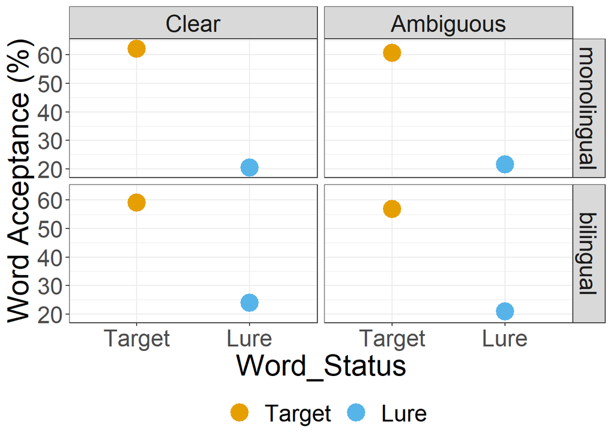

### English CLT

#### Overall performance

```
## Generalized linear mixed model fit by maximum likelihood (Laplace
##   Approximation) [glmerMod]
##  Family: binomial  ( logit )
## Formula: detection ~ 1 + Boundary_Type * Word_Status * ENG_CLT_score.c +
##     (1 | subject_nr) + (1 | Sentence_Num)
##    Data: Pseg_Htest
## Control: glmerControl(optimizer = "bobyqa")
##
##      AIC      BIC   logLik deviance df.resid
##   8624.0   8693.8  -4302.0   8604.0     7879
##
## Scaled residuals:
##     Min      1Q  Median      3Q     Max
## -6.0664 -0.6102 -0.3088  0.7042  5.0401
##
## Random effects:
##  Groups       Name        Variance Std.Dev.
##  Sentence_Num (Intercept) 0.1138   0.3374
##  subject_nr   (Intercept) 0.7415   0.8611
## Number of obs: 7889, groups:  Sentence_Num, 120; subject_nr, 105
##
## Fixed effects:
##                                              Estimate Std. Error z value
## (Intercept)                                 -0.524958   0.093960  -5.587
## Boundary_Type1                               0.075821   0.055445   1.368
## Word_Status1                                 2.020063   0.058203  34.707
## ENG_CLT_score.c                             -0.008081   0.006502  -1.243
## Boundary_Type1:Word_Status1                  0.004158   0.110762   0.038
## Boundary_Type1:ENG_CLT_score.c               0.006246   0.004222   1.479
## Word_Status1:ENG_CLT_score.c                 0.050158   0.004405  11.386
## Boundary_Type1:Word_Status1:ENG_CLT_score.c -0.018400   0.008458  -2.176
##                                             Pr(>|z|)
## (Intercept)                                 2.31e-08 ***
## Boundary_Type1                                0.1715
## Word_Status1                                 < 2e-16 ***
## ENG_CLT_score.c                               0.2139
## Boundary_Type1:Word_Status1                   0.9701
## Boundary_Type1:ENG_CLT_score.c                0.1391
## Word_Status1:ENG_CLT_score.c                 < 2e-16 ***
## Boundary_Type1:Word_Status1:ENG_CLT_score.c   0.0296 *
## ---
## Signif. codes:  0 '***' 0.001 '**' 0.01 '*' 0.05 '.' 0.1 ' ' 1
##
## Correlation of Fixed Effects:
##             (Intr) Bnd_T1 Wrd_S1 ENG_CL Bn_T1:W_S1 B_T1:E W_S1:E
## Bondry_Typ1 -0.006
## Word_Stats1 -0.068  0.027
## ENG_CLT_sc.  0.019 -0.013 -0.041
## Bnd_T1:W_S1  0.007 -0.186 -0.018  0.014
## B_T1:ENG_CL -0.013  0.142  0.044 -0.016 -0.106
## W_S1:ENG_CL -0.038  0.044  0.179 -0.095 -0.040      0.036
## B_T1:W_S1:E  0.012 -0.106 -0.040  0.013  0.140     -0.236 -0.045
```

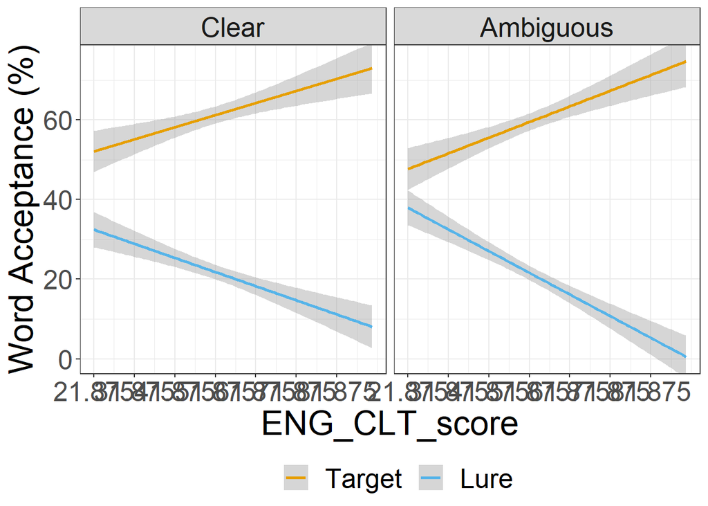

### Ravens Matricies IQ score

```
## Generalized linear mixed model fit by maximum likelihood (Laplace
##   Approximation) [glmerMod]
##  Family: binomial  ( logit )
## Formula: detection ~ 1 + Boundary_Type * Word_Status * RAVENS_IQ.c + (1 |
##     subject_nr) + (1 | Sentence_Num)
##    Data: Pseg_Htest
## Control: glmerControl(optimizer = "bobyqa")
##
##      AIC      BIC   logLik deviance df.resid
##   8568.2   8637.7  -4274.1   8548.2     7730
##
## Scaled residuals:
##     Min      1Q  Median      3Q     Max
## -5.6738 -0.6138 -0.3180  0.7093  7.9735
##
## Random effects:
##  Groups       Name        Variance Std.Dev.
##  Sentence_Num (Intercept) 0.1162   0.3408
##  subject_nr   (Intercept) 0.6766   0.8226
## Number of obs: 7740, groups:  Sentence_Num, 120; subject_nr, 103
##
## Fixed effects:
##                                          Estimate Std. Error z value Pr(>|z|)
## (Intercept)                             -0.507246   0.091404  -5.550 2.86e-08
## Boundary_Type1                           0.040330   0.055405   0.728  0.46667
## Word_Status1                             1.992400   0.057808  34.466  < 2e-16
## RAVENS_IQ.c                             -0.021312   0.007704  -2.766  0.00567
## Boundary_Type1:Word_Status1              0.027171   0.110646   0.246  0.80602
## Boundary_Type1:RAVENS_IQ.c              -0.001174   0.005111  -0.230  0.81826
## Word_Status1:RAVENS_IQ.c                 0.039868   0.005366   7.430 1.09e-13
## Boundary_Type1:Word_Status1:RAVENS_IQ.c -0.008461   0.010211  -0.829  0.40733
##
## (Intercept)                             ***
## Boundary_Type1
## Word_Status1                            ***
## RAVENS_IQ.c                             **
## Boundary_Type1:Word_Status1
## Boundary_Type1:RAVENS_IQ.c
## Word_Status1:RAVENS_IQ.c                ***
## Boundary_Type1:Word_Status1:RAVENS_IQ.c
## ---
## Signif. codes:  0 '***' 0.001 '**' 0.01 '*' 0.05 '.' 0.1 ' ' 1
##
## Correlation of Fixed Effects:
##             (Intr) Bnd_T1 Wrd_S1 RAVENS Bn_T1:W_S1 B_T1:R W_S1:R
## Bondry_Typ1  0.000
## Word_Stats1 -0.069  0.007
## RAVENS_IQ.c  0.016 -0.001 -0.049
## Bnd_T1:W_S1  0.001 -0.182  0.002  0.001
## B_T1:RAVENS -0.003  0.119  0.003 -0.002 -0.121
## W_S1:RAVENS -0.045  0.002  0.142 -0.102 -0.006      0.013
## B_T1:W_S1:R  0.000 -0.122 -0.008  0.002  0.119     -0.249 -0.004
```

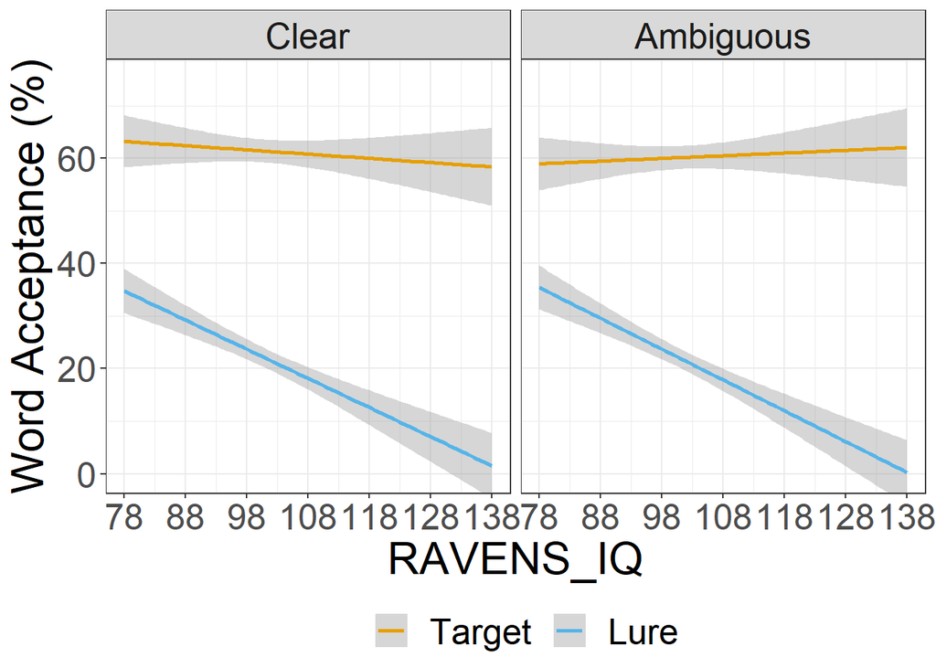

### Backwards Digit Span

```
## Generalized linear mixed model fit by maximum likelihood (Laplace
##   Approximation) [glmerMod]
##  Family: binomial  ( logit )
## Formula: detection ~ 1 + Boundary_Type * Word_Status * WM_BackDigitSpan.c +
##     (1 | subject_nr) + (1 | Sentence_Num)
##    Data: Pseg_Htest
## Control: glmerControl(optimizer = "bobyqa")
##
##      AIC      BIC   logLik deviance df.resid
##   8768.6   8838.5  -4374.3   8748.6     7957
##
## Scaled residuals:
##     Min      1Q  Median      3Q     Max
## -4.1185 -0.6100 -0.3301  0.7013  5.3388
##
## Random effects:
##  Groups       Name        Variance Std.Dev.
##  Sentence_Num (Intercept) 0.1155   0.3399
##  subject_nr   (Intercept) 0.6765   0.8225
## Number of obs: 7967, groups:  Sentence_Num, 120; subject_nr, 106
##
## Fixed effects:
##                                                Estimate Std. Error z value
## (Intercept)                                    -0.51963    0.09019  -5.762
## Boundary_Type1                                  0.03683    0.05448   0.676
## Word_Status1                                    1.99079    0.05681  35.040
## WM_BackDigitSpan.c                             -0.18877    0.09656  -1.955
## Boundary_Type1:Word_Status1                     0.07490    0.10883   0.688
## Boundary_Type1:WM_BackDigitSpan.c              -0.04028    0.06361  -0.633
## Word_Status1:WM_BackDigitSpan.c                 0.53053    0.06528   8.127
## Boundary_Type1:Word_Status1:WM_BackDigitSpan.c  0.22836    0.12724   1.795
##                                                Pr(>|z|)
## (Intercept)                                    8.33e-09 ***
## Boundary_Type1                                   0.4990
## Word_Status1                                    < 2e-16 ***
## WM_BackDigitSpan.c                               0.0506 .
## Boundary_Type1:Word_Status1                      0.4913
## Boundary_Type1:WM_BackDigitSpan.c                0.5266
## Word_Status1:WM_BackDigitSpan.c                4.40e-16 ***
## Boundary_Type1:Word_Status1:WM_BackDigitSpan.c   0.0727 .
## ---
## Signif. codes:  0 '***' 0.001 '**' 0.01 '*' 0.05 '.' 0.1 ' ' 1
##
## Correlation of Fixed Effects:
##             (Intr) Bnd_T1 Wrd_S1 WM_BDS Bn_T1:W_S1 B_T1:WM W_S1:W
## Bondry_Typ1  0.004
## Word_Stats1 -0.067 -0.003
## WM_BckDgtS.  0.017  0.007 -0.025
## Bnd_T1:W_S1 -0.003 -0.177  0.015 -0.004
## B_T1:WM_BDS  0.007  0.072 -0.012  0.007 -0.069
## W_S1:WM_BDS -0.025 -0.011  0.089 -0.044  0.025     -0.015
## B_T1:W_S1:W -0.004 -0.068  0.028 -0.006  0.072     -0.127   0.017
```

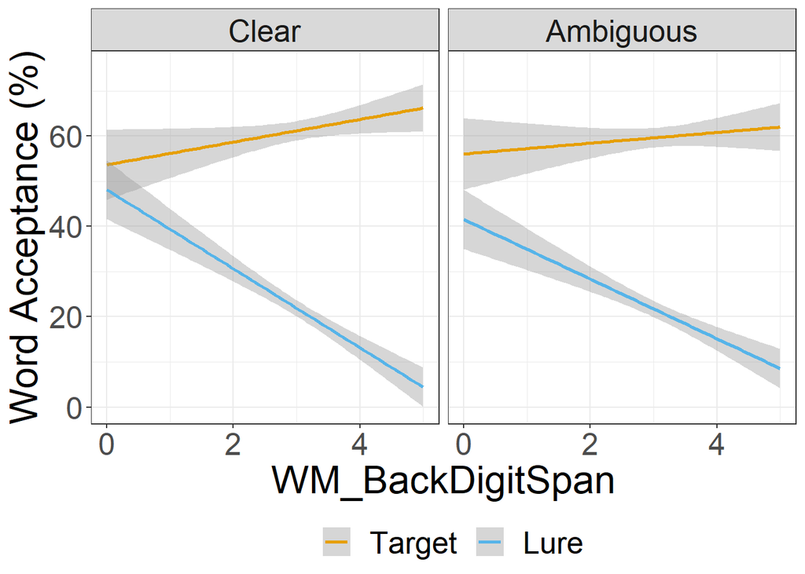

### NonWord Repetition Task

```
## Generalized linear mixed model fit by maximum likelihood (Laplace
##   Approximation) [glmerMod]
##  Family: binomial  ( logit )
## Formula: detection ~ 1 + Boundary_Type * Word_Status * NWRT_total_correct.c +
##     (1 | subject_nr) + (1 | Sentence_Num)
##    Data: Pseg_Htest
## Control: glmerControl(optimizer = "bobyqa")
##
##      AIC      BIC   logLik deviance df.resid
##   8823.9   8893.7  -4401.9   8803.9     7957
##
## Scaled residuals:
##     Min      1Q  Median      3Q     Max
## -6.0260 -0.6042 -0.3411  0.7096  5.6256
##
## Random effects:
##  Groups       Name        Variance Std.Dev.
##  Sentence_Num (Intercept) 0.1135   0.3370
##  subject_nr   (Intercept) 0.7108   0.8431
## Number of obs: 7967, groups:  Sentence_Num, 120; subject_nr, 106
##
## Fixed effects:
##                                                   Estimate Std. Error z value
## (Intercept)                                      -0.509112   0.091792  -5.546
## Boundary_Type1                                    0.045510   0.054026   0.842
## Word_Status1                                      1.979008   0.056390  35.095
## NWRT_total_correct.c                             -0.035272   0.040575  -0.869
## Boundary_Type1:Word_Status1                       0.051405   0.107928   0.476
## Boundary_Type1:NWRT_total_correct.c               0.024490   0.025130   0.975
## Word_Status1:NWRT_total_correct.c                 0.103897   0.025711   4.041
## Boundary_Type1:Word_Status1:NWRT_total_correct.c  0.003526   0.050177   0.070
##                                                  Pr(>|z|)
## (Intercept)                                      2.92e-08 ***
## Boundary_Type1                                      0.400
## Word_Status1                                      < 2e-16 ***
## NWRT_total_correct.c                                0.385
## Boundary_Type1:Word_Status1                         0.634
## Boundary_Type1:NWRT_total_correct.c                 0.330
## Word_Status1:NWRT_total_correct.c                5.32e-05 ***
## Boundary_Type1:Word_Status1:NWRT_total_correct.c    0.944
## ---
## Signif. codes:  0 '***' 0.001 '**' 0.01 '*' 0.05 '.' 0.1 ' ' 1
##
## Correlation of Fixed Effects:
##             (Intr) Bnd_T1 Wrd_S1 NWRT__ Bn_T1:W_S1 B_T1:N W_S1:N
## Bondry_Typ1  0.001
## Word_Stats1 -0.060  0.007
## NWRT_ttl_c.  0.006 -0.001 -0.015
## Bnd_T1:W_S1  0.001 -0.163  0.005  0.002
## B_T1:NWRT__ -0.001  0.034  0.006  0.000 -0.041
## W_S1:NWRT__ -0.015  0.006  0.041 -0.051 -0.005      0.008
## B_T1:W_S1:N  0.001 -0.043 -0.004  0.003  0.037     -0.152  0.002
```

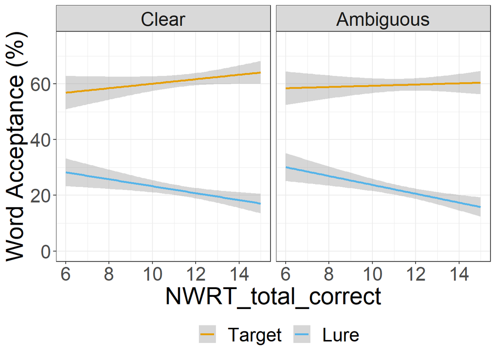

# Role of Phonotactics on Target Detection

In these analyses, only the targets are analyzed

## Main Analysis: Word Candidate Length by Boundary Type

```
## Generalized linear mixed model fit by maximum likelihood (Laplace
##   Approximation) [glmerMod]
##  Family: binomial  ( logit )
## Formula: detection ~ 1 + Word_Candidate_Length * Boundary_Type + (1 |
##     subject_nr) + (1 | Sentence_Num)
##    Data: Pseg_Htest
## Control: glmerControl(optimizer = "bobyqa")
##
##      AIC      BIC   logLik deviance df.resid
##  10031.8  10073.7  -5009.9  10019.8     7957
##
## Scaled residuals:
##     Min      1Q  Median      3Q     Max
## -4.3349 -0.9010  0.4547  0.7944  3.5673
##
## Random effects:
##  Groups       Name        Variance Std.Dev.
##  Sentence_Num (Intercept) 0.2007   0.4480
##  subject_nr   (Intercept) 0.7129   0.8443
## Number of obs: 7963, groups:  Sentence_Num, 120; subject_nr, 106
##
## Fixed effects:
##                                       Estimate Std. Error z value Pr(>|z|)
## (Intercept)                            0.18463    0.09504   1.943   0.0521 .
## Word_Candidate_Length1                -0.57458    0.04935 -11.642   <2e-16 ***
## Boundary_Type1                         0.06960    0.04910   1.418   0.1563
## Word_Candidate_Length1:Boundary_Type1 -0.01781    0.09814  -0.182   0.8560
## ---
## Signif. codes:  0 '***' 0.001 '**' 0.01 '*' 0.05 '.' 0.1 ' ' 1
##
## Correlation of Fixed Effects:
##             (Intr) Wr_C_L1 Bnd_T1
## Wrd_Cndd_L1 -0.006
## Bondry_Typ1  0.001 -0.006
## W_C_L1:B_T1 -0.002  0.005  -0.023
```

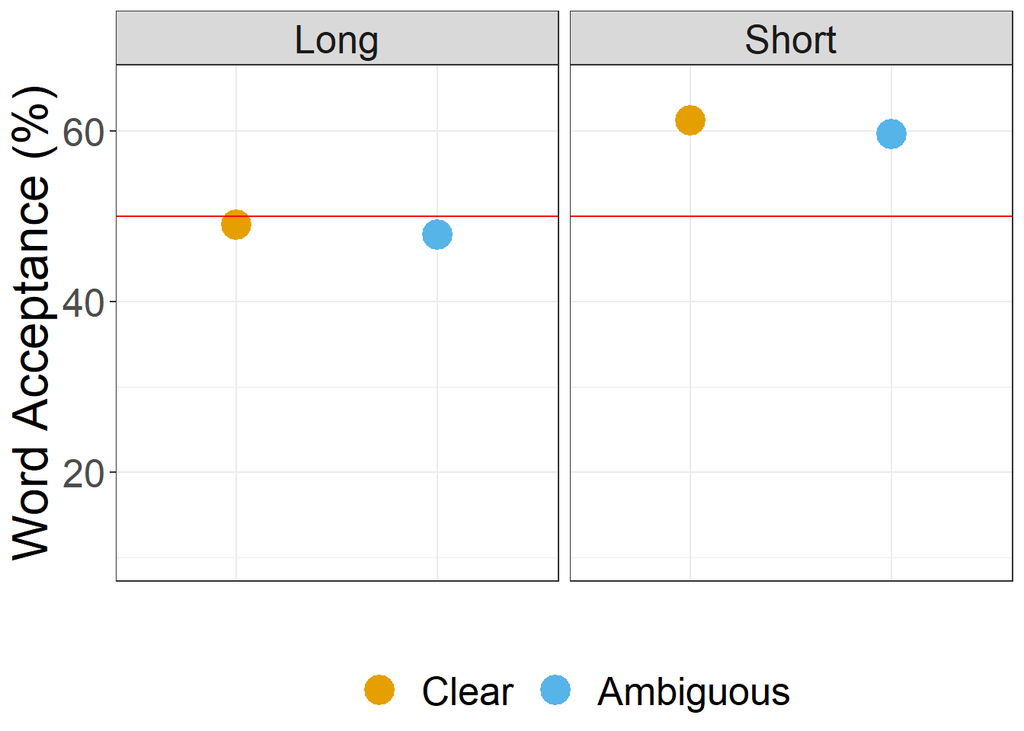

### Role of Phonological Awareness, with control variables Ravens IQ, Working Memory, and German CLT

```
## Generalized linear mixed model fit by maximum likelihood (Laplace
##   Approximation) [glmerMod]
##  Family: binomial  ( logit )
## Formula:
## detection ~ 1 + Word_Candidate_Length * Boundary_Type * Phoneme_Manipulation.c +
##     RAVENS_IQ + Ger_CLT_Prod.c + WM_BackDigitSpan.c + (1 | subject_nr) +
##     (1 | Sentence_Num)
##    Data: Pseg_Htest
## Control: glmerControl(optimizer = "bobyqa")
##
##      AIC      BIC   logLik deviance df.resid
##   9654.7   9745.0  -4814.3   9628.7     7644
##
## Scaled residuals:
##     Min      1Q  Median      3Q     Max
## -4.3242 -0.9070  0.4544  0.7975  3.4010
##
## Random effects:
##  Groups       Name        Variance Std.Dev.
##  Sentence_Num (Intercept) 0.1999   0.4471
##  subject_nr   (Intercept) 0.6792   0.8241
## Number of obs: 7657, groups:  Sentence_Num, 120; subject_nr, 102
##
## Fixed effects:
##                                                               Estimate
## (Intercept)                                                   0.678869
## Word_Candidate_Length1                                       -0.585708
## Boundary_Type1                                                0.059974
## Phoneme_Manipulation.c                                        0.056180
## RAVENS_IQ                                                    -0.004772
## Ger_CLT_Prod.c                                               -0.030263
## WM_BackDigitSpan.c                                           -0.060583
## Word_Candidate_Length1:Boundary_Type1                         0.001445
## Word_Candidate_Length1:Phoneme_Manipulation.c                -0.037435
## Boundary_Type1:Phoneme_Manipulation.c                         0.007292
## Word_Candidate_Length1:Boundary_Type1:Phoneme_Manipulation.c -0.006910
##                                                              Std. Error z value
## (Intercept)                                                    0.787008   0.863
## Word_Candidate_Length1                                         0.050362 -11.630
## Boundary_Type1                                                 0.050110   1.197
```

[output cut: 35 more lines]

```
##              W_C_L1:P B_T1:P
## Wrd_Cndd_L1
## Bondry_Typ1
## Phnm_Mnplt.
## RAVENS_IQ
## Gr_CLT_Prd.
## WM_BckDgtS.
## Wr_C_L1:B_T1
## W_C_L1:P_M.
## Bnd_T1:P_M.  -0.018
## W_C_L1:B_T1:  0.014   -0.048
## optimizer (bobyqa) convergence code: 1 (bobyqa -- maximum number of function evaluations exceeded)
## Model failed to converge with max|grad| = 0.023784 (tol = 0.002, component 1)
## Model is nearly unidentifiable: very large eigenvalue
##  - Rescale variables?
```

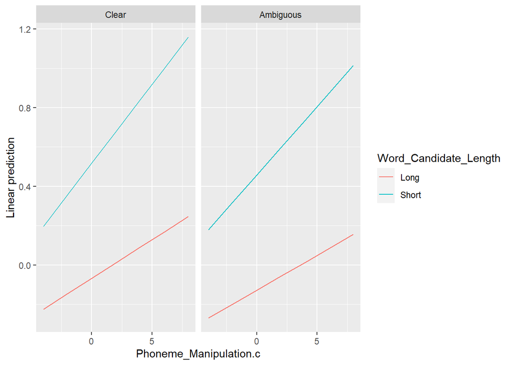

## Experiment Task Variables

### Trial by Word Candidate Length by Boundary Type

```
## Generalized linear mixed model fit by maximum likelihood (Laplace
##   Approximation) [glmerMod]
##  Family: binomial  ( logit )
## Formula: detection ~ 1 + Word_Candidate_Length * Boundary_Type * Trial.c +
##     (1 | subject_nr) + (1 | Sentence_Num)
##    Data: Pseg_Htest
## Control: glmerControl(optimizer = "bobyqa")
##
##      AIC      BIC   logLik deviance df.resid
##  10033.5  10103.3  -5006.7  10013.5     7953
##
## Scaled residuals:
##     Min      1Q  Median      3Q     Max
## -4.4625 -0.8968  0.4538  0.7965  3.5458
##
## Random effects:
##  Groups       Name        Variance Std.Dev.
##  Sentence_Num (Intercept) 0.2025   0.4500
##  subject_nr   (Intercept) 0.7155   0.8459
## Number of obs: 7963, groups:  Sentence_Num, 120; subject_nr, 106
##
## Fixed effects:
##                                                 Estimate Std. Error z value
## (Intercept)                                    0.1846410  0.0952588   1.938
## Word_Candidate_Length1                        -0.5776029  0.0494027 -11.692
## Boundary_Type1                                 0.0710094  0.0491453   1.445
## Trial.c                                       -0.0017695  0.0007133  -2.481
## Word_Candidate_Length1:Boundary_Type1         -0.0176961  0.0982375  -0.180
## Word_Candidate_Length1:Trial.c                -0.0002621  0.0014301  -0.183
## Boundary_Type1:Trial.c                        -0.0003617  0.0014272  -0.253
## Word_Candidate_Length1:Boundary_Type1:Trial.c -0.0008367  0.0028585  -0.293
##                                               Pr(>|z|)
## (Intercept)                                     0.0526 .
## Word_Candidate_Length1                          <2e-16 ***
## Boundary_Type1                                  0.1485
## Trial.c                                         0.0131 *
## Word_Candidate_Length1:Boundary_Type1           0.8570
## Word_Candidate_Length1:Trial.c                  0.8546
## Boundary_Type1:Trial.c                          0.7999
## Word_Candidate_Length1:Boundary_Type1:Trial.c   0.7697
## ---
## Signif. codes:  0 '***' 0.001 '**' 0.01 '*' 0.05 '.' 0.1 ' ' 1
##
## Correlation of Fixed Effects:
##              (Intr) Wr_C_L1 Bnd_T1 Tril.c Wr_C_L1:B_T1 W_C_L1:T B_T1:T
## Wrd_Cndd_L1  -0.006
## Bondry_Typ1   0.001 -0.007
## Trial.c      -0.001  0.030  -0.015
## Wr_C_L1:B_T1 -0.002  0.005  -0.023 -0.001
## Wrd_C_L1:T.   0.007 -0.004  -0.001 -0.012 -0.015
## Bndry_T1:T.  -0.003 -0.002  -0.004  0.008  0.027       -0.009
## W_C_L1:B_T1:  0.000 -0.014   0.027 -0.011 -0.003        0.008   -0.012
## optimizer (bobyqa) convergence code: 0 (OK)
## Model is nearly unidentifiable: very large eigenvalue
##  - Rescale variables?
```

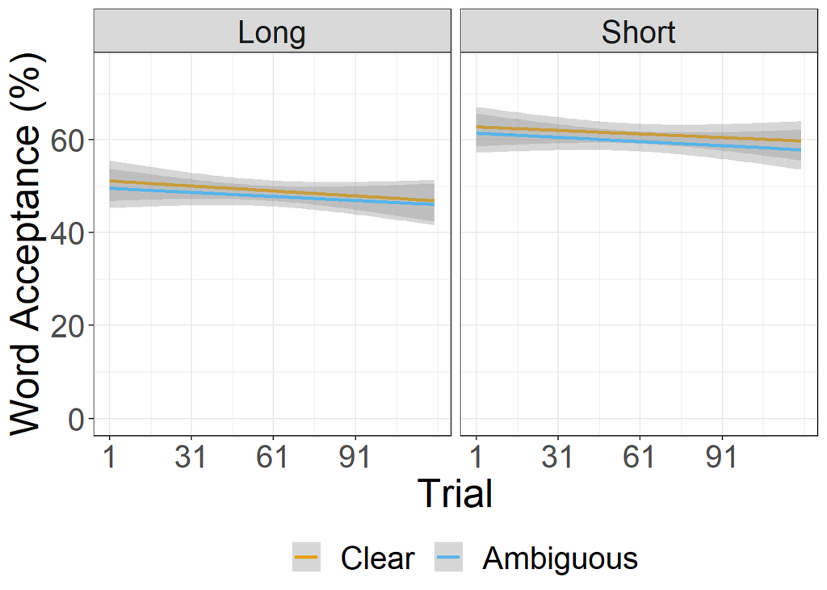

### Counterbalance List by Word Candidate Length by Boundary Type

```
## # A tibble: 6 × 2
##   List  total_participants
##   <fct>              <int>
## 1 A                     21
## 2 B                     18
## 3 C                     18
## 4 D                     16
## 5 E                     16
## 6 F                     17
```

```
## Generalized linear mixed model fit by maximum likelihood (Laplace
##   Approximation) [glmerMod]
##  Family: binomial  ( logit )
## Formula: detection ~ 1 + Word_Candidate_Length * Boundary_Type * List +
##     (1 | subject_nr) + (1 | Sentence_Num)
##    Data: Pseg_Htest
## Control: glmerControl(optimizer = "bobyqa")
##
##      AIC      BIC   logLik deviance df.resid
##  10038.0  10219.5  -4993.0   9986.0     7937
##
## Scaled residuals:
##     Min      1Q  Median      3Q     Max
## -4.1451 -0.8961  0.4494  0.7935  3.9930
##
## Random effects:
##  Groups       Name        Variance Std.Dev.
##  Sentence_Num (Intercept) 0.1958   0.4425
##  subject_nr   (Intercept) 0.6810   0.8252
## Number of obs: 7963, groups:  Sentence_Num, 120; subject_nr, 106
##
## Fixed effects:
##                                             Estimate Std. Error z value
## (Intercept)                                  0.16364    0.19535   0.838
## Word_Candidate_Length1                      -0.50778    0.14840  -3.422
## Boundary_Type1                               0.15713    0.14820   1.060
## ListB                                       -0.26852    0.28048  -0.957
## ListC                                        0.35571    0.28207   1.261
## ListD                                       -0.04785    0.29118  -0.164
## ListE                                        0.01614    0.29088   0.056
## ListF                                        0.06961    0.28503   0.244
## Word_Candidate_Length1:Boundary_Type1       -0.07281    0.29625  -0.246
## Word_Candidate_Length1:ListB                -0.01979    0.20238  -0.098
## Word_Candidate_Length1:ListC                 0.12725    0.23580   0.540
## Word_Candidate_Length1:ListD                -0.13317    0.24020  -0.554
## Word_Candidate_Length1:ListE                -0.24798    0.23905  -1.037
## Word_Candidate_Length1:ListF                -0.18002    0.20800  -0.865
## Boundary_Type1:ListB                        -0.16975    0.24587  -0.690
## Boundary_Type1:ListC                         0.05275    0.18962   0.278
## Boundary_Type1:ListD                        -0.28666    0.23982  -1.195
```

[output cut: 19 more lines]

```
## Word_Candidate_Length1:ListD                0.579281
## Word_Candidate_Length1:ListE                0.299581
## Word_Candidate_Length1:ListF                0.386774
## Boundary_Type1:ListB                        0.489937
## Boundary_Type1:ListC                        0.780866
## Boundary_Type1:ListD                        0.231978
## Boundary_Type1:ListE                        0.401160
## Boundary_Type1:ListF                        0.877611
## Word_Candidate_Length1:Boundary_Type1:ListB 0.672425
## Word_Candidate_Length1:Boundary_Type1:ListC 0.834066
## Word_Candidate_Length1:Boundary_Type1:ListD 0.684510
## Word_Candidate_Length1:Boundary_Type1:ListE 0.066716 .
## Word_Candidate_Length1:Boundary_Type1:ListF 0.079181 .
## ---
## Signif. codes:  0 '***' 0.001 '**' 0.01 '*' 0.05 '.' 0.1 ' ' 1
```

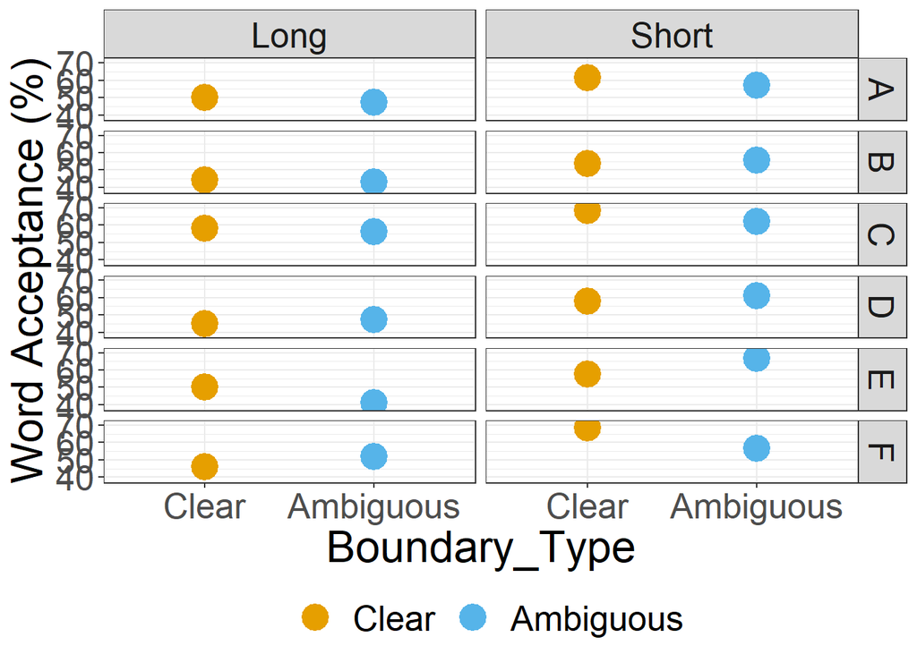

### Word Length (monosyllabic, bisyllabic)

```
## Generalized linear mixed model fit by maximum likelihood (Laplace
##   Approximation) [glmerMod]
##  Family: binomial  ( logit )
## Formula: detection ~ 1 + Word_Candidate_Length * Boundary_Type * sylls +
##     (1 | subject_nr) + (1 | Sentence_Num)
##    Data: Pseg_Htest
## Control: glmerControl(optimizer = "bobyqa")
##
##      AIC      BIC   logLik deviance df.resid
##  10032.6  10102.5  -5006.3  10012.6     7953
##
## Scaled residuals:
##     Min      1Q  Median      3Q     Max
## -4.5729 -0.8992  0.4543  0.7943  3.7553
##
## Random effects:
##  Groups       Name        Variance Std.Dev.
##  Sentence_Num (Intercept) 0.1960   0.4427
##  subject_nr   (Intercept) 0.7132   0.8445
## Number of obs: 7963, groups:  Sentence_Num, 120; subject_nr, 106
##
## Fixed effects:
##                                              Estimate Std. Error z value
## (Intercept)                                   0.18514    0.09486   1.952
## Word_Candidate_Length1                       -0.57531    0.04937 -11.652
## Boundary_Type1                                0.06850    0.04913   1.394
## sylls1                                       -0.14106    0.09459  -1.491
## Word_Candidate_Length1:Boundary_Type1        -0.01500    0.09819  -0.153
## Word_Candidate_Length1:sylls1                 0.12483    0.09832   1.270
## Boundary_Type1:sylls1                         0.17007    0.09825   1.731
## Word_Candidate_Length1:Boundary_Type1:sylls1 -0.13517    0.19639  -0.688
##                                              Pr(>|z|)
## (Intercept)                                    0.0510 .
## Word_Candidate_Length1                         <2e-16 ***
## Boundary_Type1                                 0.1632
## sylls1                                         0.1359
## Word_Candidate_Length1:Boundary_Type1          0.8786
## Word_Candidate_Length1:sylls1                  0.2042
## Boundary_Type1:sylls1                          0.0834 .
## Word_Candidate_Length1:Boundary_Type1:sylls1   0.4913
## ---
## Signif. codes:  0 '***' 0.001 '**' 0.01 '*' 0.05 '.' 0.1 ' ' 1
##
## Correlation of Fixed Effects:
##              (Intr) Wr_C_L1 Bnd_T1 sylls1 Wr_C_L1:B_T1 W_C_L1:1 B_T1:1
## Wrd_Cndd_L1  -0.006
## Bondry_Typ1   0.001 -0.005
## sylls1       -0.001  0.010   0.001
## Wr_C_L1:B_T1 -0.001  0.004  -0.025 -0.001
## Wrd_Cn_L1:1   0.004 -0.010  -0.002 -0.013  0.002
## Bndry_Ty1:1   0.001 -0.003  -0.010  0.002  0.016       -0.004
## W_C_L1:B_T1:  0.000  0.003   0.016 -0.003 -0.010        0.004   -0.025
```

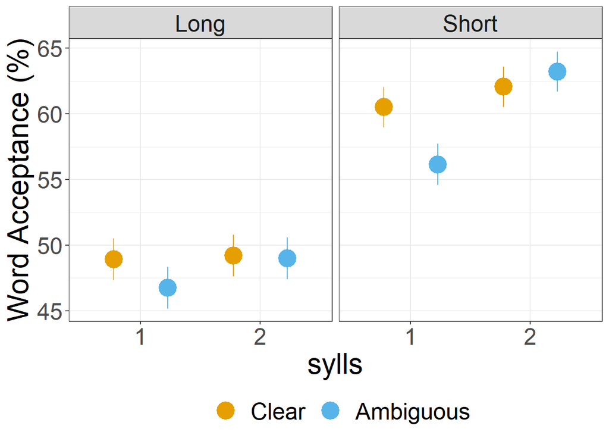

### Onset Boundary Context (sibilant, nonsibilant)

```
## Generalized linear mixed model fit by maximum likelihood (Laplace
##   Approximation) [glmerMod]
##  Family: binomial  ( logit )
## Formula: detection ~ 1 + Word_Candidate_Length * Boundary_Type * Context1 +
##     (1 | subject_nr) + (1 | Sentence_Num)
##    Data: Pseg_Htest
## Control: glmerControl(optimizer = "bobyqa")
##
##      AIC      BIC   logLik deviance df.resid
##  10030.4  10100.3  -5005.2  10010.4     7953
##
## Scaled residuals:
##     Min      1Q  Median      3Q     Max
## -4.4099 -0.8987  0.4535  0.7918  3.6204
##
## Random effects:
##  Groups       Name        Variance Std.Dev.
##  Sentence_Num (Intercept) 0.1944   0.4410
##  subject_nr   (Intercept) 0.7143   0.8452
## Number of obs: 7963, groups:  Sentence_Num, 120; subject_nr, 106
##
## Fixed effects:
##                                                 Estimate Std. Error z value
## (Intercept)                                      0.18464    0.09484   1.947
## Word_Candidate_Length1                          -0.57385    0.04937 -11.623
## Boundary_Type1                                   0.06914    0.04912   1.407
## Context11                                        0.16484    0.09432   1.748
## Word_Candidate_Length1:Boundary_Type1           -0.01525    0.09819  -0.155
## Word_Candidate_Length1:Context11                 0.12396    0.09834   1.261
## Boundary_Type1:Context11                         0.03324    0.09826   0.338
## Word_Candidate_Length1:Boundary_Type1:Context11  0.42147    0.19641   2.146
##                                                 Pr(>|z|)
## (Intercept)                                       0.0516 .
## Word_Candidate_Length1                            <2e-16 ***
## Boundary_Type1                                    0.1593
## Context11                                         0.0805 .
## Word_Candidate_Length1:Boundary_Type1             0.8766
## Word_Candidate_Length1:Context11                  0.2075
## Boundary_Type1:Context11                          0.7351
## Word_Candidate_Length1:Boundary_Type1:Context11   0.0319 *
## ---
## Signif. codes:  0 '***' 0.001 '**' 0.01 '*' 0.05 '.' 0.1 ' ' 1
##
## Correlation of Fixed Effects:
##              (Intr) Wr_C_L1 Bnd_T1 Cntx11 Wr_C_L1:B_T1 W_C_L1:C B_T1:C
## Wrd_Cndd_L1  -0.006
## Bondry_Typ1   0.001 -0.005
## Context11     0.001 -0.005   0.000
## Wr_C_L1:B_T1 -0.001  0.006  -0.022  0.002
## Wr_C_L1:C11  -0.002  0.010   0.004 -0.012 -0.001
## Bndr_T1:C11   0.000  0.003   0.011  0.003 -0.007       -0.004
## W_C_L1:B_T1:  0.001 -0.003  -0.007 -0.002  0.011        0.006   -0.022
```

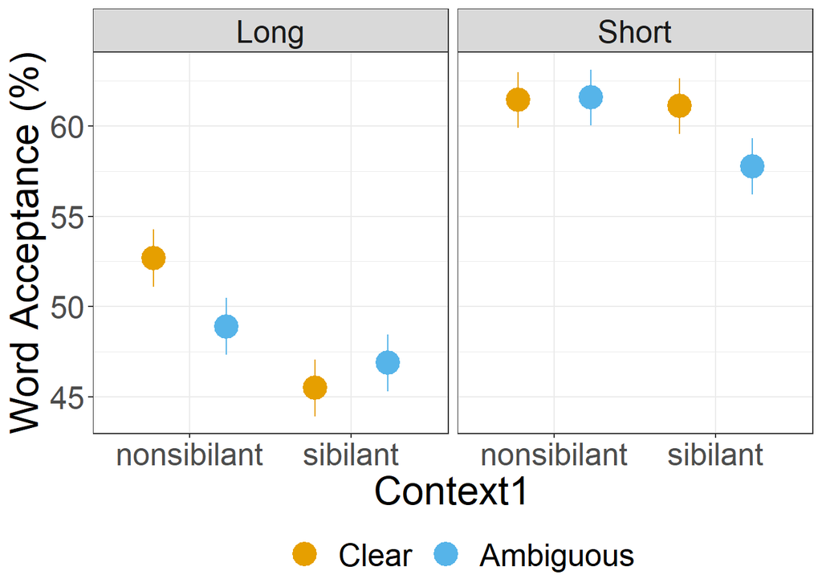

### Coda Boundary Context (liquid, stop, vowel, fricative)

```
## Generalized linear mixed model fit by maximum likelihood (Laplace
##   Approximation) [glmerMod]
##  Family: binomial  ( logit )
## Formula: detection ~ 1 + Word_Candidate_Length * Boundary_Type * Context2 +
##     (1 | subject_nr) + (1 | Sentence_Num)
##    Data: Pseg_Htest
## Control: glmerControl(optimizer = "bobyqa")
##
##      AIC      BIC   logLik deviance df.resid
##  10047.6  10173.3  -5005.8  10011.6     7945
##
## Scaled residuals:
##     Min      1Q  Median      3Q     Max
## -4.2909 -0.8975  0.4518  0.7945  3.5065
##
## Random effects:
##  Groups       Name        Variance Std.Dev.
##  Sentence_Num (Intercept) 0.1977   0.4446
##  subject_nr   (Intercept) 0.7149   0.8455
## Number of obs: 7963, groups:  Sentence_Num, 120; subject_nr, 106
##
## Fixed effects:
##                                                  Estimate Std. Error z value
## (Intercept)                                      0.240705   0.106256   2.265
## Word_Candidate_Length1                          -0.545539   0.070156  -7.776
## Boundary_Type1                                   0.074482   0.070357   1.059
## Context22                                       -0.116032   0.097596  -1.189
## Context23                                       -0.119152   0.267658  -0.445
## Context24                                        0.025086   0.375538   0.067
## Word_Candidate_Length1:Boundary_Type1            0.122631   0.139826   0.877
## Word_Candidate_Length1:Context22                -0.067036   0.102250  -0.656
## Word_Candidate_Length1:Context23                 0.215763   0.277327   0.778
## Word_Candidate_Length1:Context24                -0.469472   0.394961  -1.189
## Boundary_Type1:Context22                        -0.009791   0.103563  -0.095
## Boundary_Type1:Context23                        -0.130348   0.277143  -0.470
## Boundary_Type1:Context24                         0.086715   0.396165   0.219
## Word_Candidate_Length1:Boundary_Type1:Context22 -0.241473   0.204599  -1.180
## Word_Candidate_Length1:Boundary_Type1:Context23 -0.948705   0.551245  -1.721
## Word_Candidate_Length1:Boundary_Type1:Context24  0.001210   0.789319   0.002
##                                                 Pr(>|z|)
## (Intercept)                                       0.0235 *
## Word_Candidate_Length1                          7.48e-15 ***
## Boundary_Type1                                    0.2898
## Context22                                         0.2345
## Context23                                         0.6562
## Context24                                         0.9467
## Word_Candidate_Length1:Boundary_Type1             0.3805
## Word_Candidate_Length1:Context22                  0.5121
## Word_Candidate_Length1:Context23                  0.4366
## Word_Candidate_Length1:Context24                  0.2346
## Boundary_Type1:Context22                          0.9247
## Boundary_Type1:Context23                          0.6381
## Boundary_Type1:Context24                          0.8267
## Word_Candidate_Length1:Boundary_Type1:Context22   0.2379
## Word_Candidate_Length1:Boundary_Type1:Context23   0.0852 .
## Word_Candidate_Length1:Boundary_Type1:Context24   0.9988
## ---
## Signif. codes:  0 '***' 0.001 '**' 0.01 '*' 0.05 '.' 0.1 ' ' 1
```

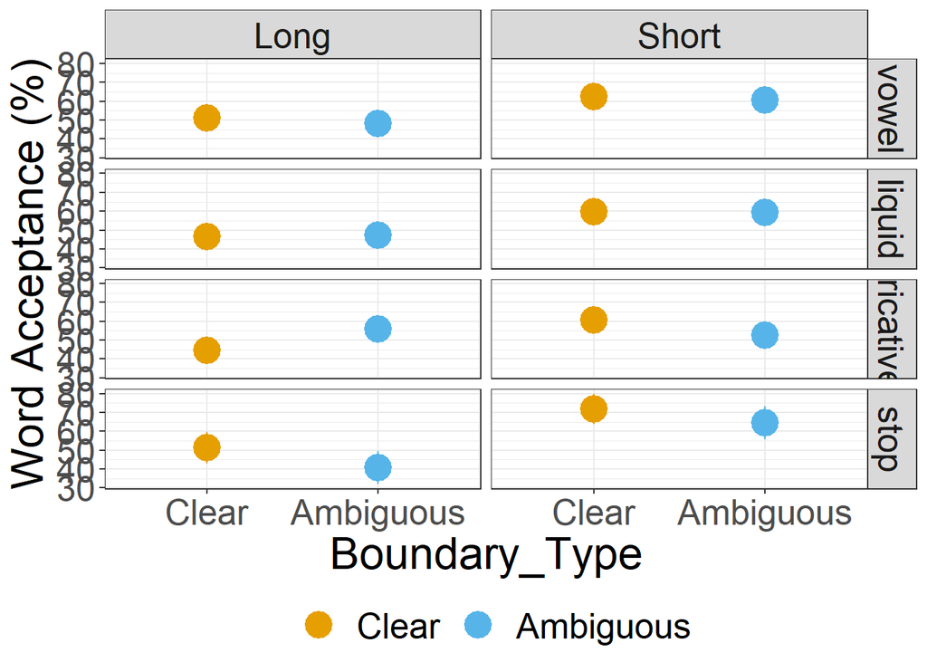

## Participant Variables: Predictors

## Correlation Individual Differences

Take with a grain of salt, these scores are the “grob” ones coded during the experiment and for some participants there are missing values (for unsure codes), but this should be fairly close to what the final coded values will be.

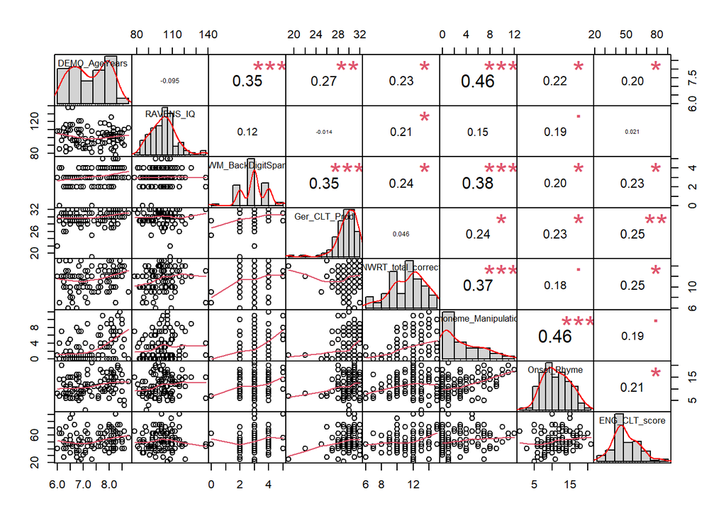

### Phonological Awareness by Word Candidate Length by Boundary Type

#### Phoneme Manipulation task score

```
## Generalized linear mixed model fit by maximum likelihood (Laplace
##   Approximation) [glmerMod]
##  Family: binomial  ( logit )
## Formula:
## detection ~ 1 + Word_Candidate_Length * Boundary_Type * Phoneme_Manipulation.c +
##     (1 | subject_nr) + (1 | Sentence_Num)
##    Data: Pseg_Htest
## Control: glmerControl(optimizer = "bobyqa")
##
##      AIC      BIC   logLik deviance df.resid
##   9921.1   9990.8  -4950.5   9901.1     7875
##
## Scaled residuals:
##     Min      1Q  Median      3Q     Max
## -4.1730 -0.8983  0.4455  0.7946  3.5500
##
## Random effects:
##  Groups       Name        Variance Std.Dev.
##  Sentence_Num (Intercept) 0.2021   0.4496
##  subject_nr   (Intercept) 0.6998   0.8365
## Number of obs: 7885, groups:  Sentence_Num, 120; subject_nr, 105
##
## Fixed effects:
##                                                               Estimate
## (Intercept)                                                   0.187685
## Word_Candidate_Length1                                       -0.577603
## Boundary_Type1                                                0.067263
## Phoneme_Manipulation.c                                        0.046124
## Word_Candidate_Length1:Boundary_Type1                        -0.023326
## Word_Candidate_Length1:Phoneme_Manipulation.c                -0.038827
## Boundary_Type1:Phoneme_Manipulation.c                         0.008744
## Word_Candidate_Length1:Boundary_Type1:Phoneme_Manipulation.c -0.007644
##                                                              Std. Error z value
## (Intercept)                                                    0.094836   1.979
## Word_Candidate_Length1                                         0.049654 -11.633
## Boundary_Type1                                                 0.049446   1.360
## Phoneme_Manipulation.c                                         0.026443   1.744
## Word_Candidate_Length1:Boundary_Type1                          0.098807  -0.236
## Word_Candidate_Length1:Phoneme_Manipulation.c                  0.015420  -2.518
## Boundary_Type1:Phoneme_Manipulation.c                          0.015371   0.569
## Word_Candidate_Length1:Boundary_Type1:Phoneme_Manipulation.c   0.030909  -0.247
##                                                              Pr(>|z|)
## (Intercept)                                                    0.0478 *
## Word_Candidate_Length1                                         <2e-16 ***
## Boundary_Type1                                                 0.1737
## Phoneme_Manipulation.c                                         0.0811 .
## Word_Candidate_Length1:Boundary_Type1                          0.8134
## Word_Candidate_Length1:Phoneme_Manipulation.c                  0.0118 *
## Boundary_Type1:Phoneme_Manipulation.c                          0.5694
## Word_Candidate_Length1:Boundary_Type1:Phoneme_Manipulation.c   0.8047
## ---
## Signif. codes:  0 '***' 0.001 '**' 0.01 '*' 0.05 '.' 0.1 ' ' 1
##
## Correlation of Fixed Effects:
##              (Intr) Wr_C_L1 Bnd_T1 Phn_M. Wr_C_L1:B_T1 W_C_L1:P B_T1:P
## Wrd_Cndd_L1  -0.007
## Bondry_Typ1   0.001 -0.007
## Phnm_Mnplt.   0.003 -0.009   0.002
## Wr_C_L1:B_T1 -0.002  0.006  -0.026  0.000
## W_C_L1:P_M.  -0.007  0.005   0.000 -0.015  0.007
## Bnd_T1:P_M.   0.002  0.000   0.005  0.005 -0.026       -0.020
## W_C_L1:B_T1:  0.000  0.006  -0.025 -0.002  0.001        0.016   -0.049
```

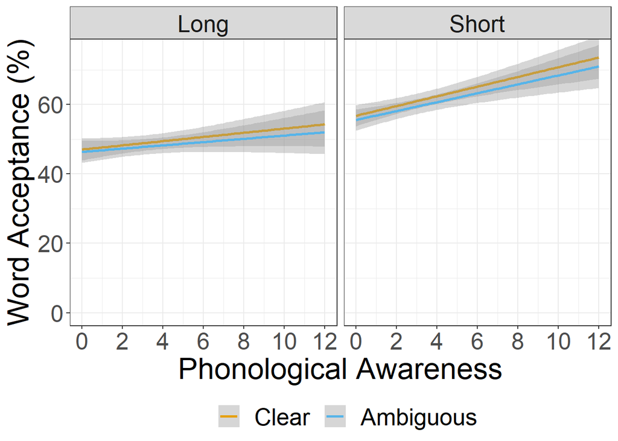

#### Onset/Rhyme Score

```
## Generalized linear mixed model fit by maximum likelihood (Laplace
##   Approximation) [glmerMod]
##  Family: binomial  ( logit )
## Formula:
## detection ~ 1 + Word_Candidate_Length * Boundary_Type * Onset_Rhyme.c +
##     (1 | subject_nr) + (1 | Sentence_Num)
##    Data: Pseg_Htest
## Control: glmerControl(optimizer = "bobyqa")
##
##      AIC      BIC   logLik deviance df.resid
##   9820.6   9890.3  -4900.3   9800.6     7802
##
## Scaled residuals:
##     Min      1Q  Median      3Q     Max
## -4.1235 -0.8941  0.4443  0.7937  3.5271
##
## Random effects:
##  Groups       Name        Variance Std.Dev.
##  Sentence_Num (Intercept) 0.2018   0.4492
##  subject_nr   (Intercept) 0.7319   0.8555
## Number of obs: 7812, groups:  Sentence_Num, 120; subject_nr, 104
##
## Fixed effects:
##                                                       Estimate Std. Error
## (Intercept)                                          0.1844013  0.0968075
## Word_Candidate_Length1                              -0.5725920  0.0499371
## Boundary_Type1                                       0.0665567  0.0496929
## Onset_Rhyme.c                                        0.0005991  0.0213205
## Word_Candidate_Length1:Boundary_Type1               -0.0113457  0.0993420
## Word_Candidate_Length1:Onset_Rhyme.c                -0.0456205  0.0120211
## Boundary_Type1:Onset_Rhyme.c                        -0.0035828  0.0119851
## Word_Candidate_Length1:Boundary_Type1:Onset_Rhyme.c  0.0116854  0.0239711
##                                                     z value Pr(>|z|)
## (Intercept)                                           1.905 0.056803 .
## Word_Candidate_Length1                              -11.466  < 2e-16 ***
## Boundary_Type1                                        1.339 0.180454
## Onset_Rhyme.c                                         0.028 0.977583
## Word_Candidate_Length1:Boundary_Type1                -0.114 0.909072
## Word_Candidate_Length1:Onset_Rhyme.c                 -3.795 0.000148 ***
## Boundary_Type1:Onset_Rhyme.c                         -0.299 0.764991
## Word_Candidate_Length1:Boundary_Type1:Onset_Rhyme.c   0.487 0.625918
## ---
## Signif. codes:  0 '***' 0.001 '**' 0.01 '*' 0.05 '.' 0.1 ' ' 1
##
## Correlation of Fixed Effects:
##              (Intr) Wr_C_L1 Bnd_T1 Ons_R. Wr_C_L1:B_T1 W_C_L1:O B_T1:O
## Wrd_Cndd_L1  -0.006
## Bondry_Typ1   0.001 -0.005
## Onst_Rhym.c   0.006 -0.005   0.001
## Wr_C_L1:B_T1 -0.001  0.004  -0.024  0.000
## W_C_L1:O_R.  -0.005  0.014   0.001 -0.009  0.005
## Bnd_T1:O_R.   0.001  0.001   0.010  0.002 -0.019       -0.003
## W_C_L1:B_T1:  0.001  0.005  -0.019 -0.001  0.012        0.008   -0.031
```

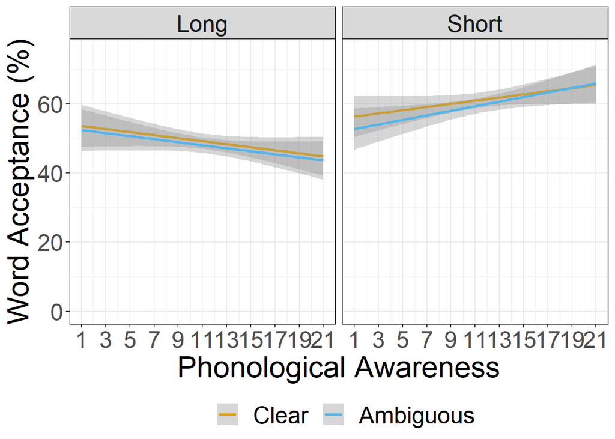

### Grade

Approximation for now for L1 knowledge

```
## Generalized linear mixed model fit by maximum likelihood (Laplace
##   Approximation) [glmerMod]
##  Family: binomial  ( logit )
## Formula:
## detection ~ 1 + Word_Candidate_Length * Boundary_Type * DEMO_SchoolGrade +
##     (1 | subject_nr) + (1 | Sentence_Num)
##    Data: Pseg_Htest
## Control: glmerControl(optimizer = "bobyqa")
##
##      AIC      BIC   logLik deviance df.resid
##  10025.6  10095.4  -5002.8  10005.6     7953
##
## Scaled residuals:
##     Min      1Q  Median      3Q     Max
## -4.1575 -0.8977  0.4514  0.7969  3.6623
##
## Random effects:
##  Groups       Name        Variance Std.Dev.
##  Sentence_Num (Intercept) 0.2022   0.4496
##  subject_nr   (Intercept) 0.6981   0.8355
## Number of obs: 7963, groups:  Sentence_Num, 120; subject_nr, 106
##
## Fixed effects:
##                                                                       Estimate
## (Intercept)                                                            0.06667
## Word_Candidate_Length1                                                -0.41427
## Boundary_Type1                                                         0.01976
## DEMO_SchoolGrade2nd grade/class                                        0.24767
## Word_Candidate_Length1:Boundary_Type1                                  0.02946
## Word_Candidate_Length1:DEMO_SchoolGrade2nd grade/class                -0.32756
## Boundary_Type1:DEMO_SchoolGrade2nd grade/class                         0.10308
## Word_Candidate_Length1:Boundary_Type1:DEMO_SchoolGrade2nd grade/class -0.10062
##                                                                       Std. Error
## (Intercept)                                                              0.12514
## Word_Candidate_Length1                                                   0.06890
## Boundary_Type1                                                           0.06876
## DEMO_SchoolGrade2nd grade/class                                          0.17007
## Word_Candidate_Length1:Boundary_Type1                                    0.13768
## Word_Candidate_Length1:DEMO_SchoolGrade2nd grade/class                   0.09869
## Boundary_Type1:DEMO_SchoolGrade2nd grade/class                           0.09837
```

[output cut: 25 more lines]

```
## Word_Candidate_Length1:DEMO_SchoolGrade2nd grade/class                ***
## Boundary_Type1:DEMO_SchoolGrade2nd grade/class
## Word_Candidate_Length1:Boundary_Type1:DEMO_SchoolGrade2nd grade/class
## ---
## Signif. codes:  0 '***' 0.001 '**' 0.01 '*' 0.05 '.' 0.1 ' ' 1
##
## Correlation of Fixed Effects:
##             (Intr) Wr_C_L1 Bnd_T1 DEMO_g W_C_L1: W_C_L1:Dg B_T1:g
## Wrd_Cndd_L1  0.000
## Bondry_Typ1  0.000 -0.004
## DEMO_ScG2g/ -0.657  0.000   0.000
## W_C_L1:B_T1  0.000  0.002  -0.006  0.000
## W_C_L1:DEMg  0.001 -0.697   0.003 -0.008 -0.002
## B_T1:DEMO_g  0.000  0.003  -0.699  0.002  0.004  -0.010
## W_C_L1:B_Tg  0.000 -0.001   0.005 -0.002 -0.700   0.007    -0.026
```

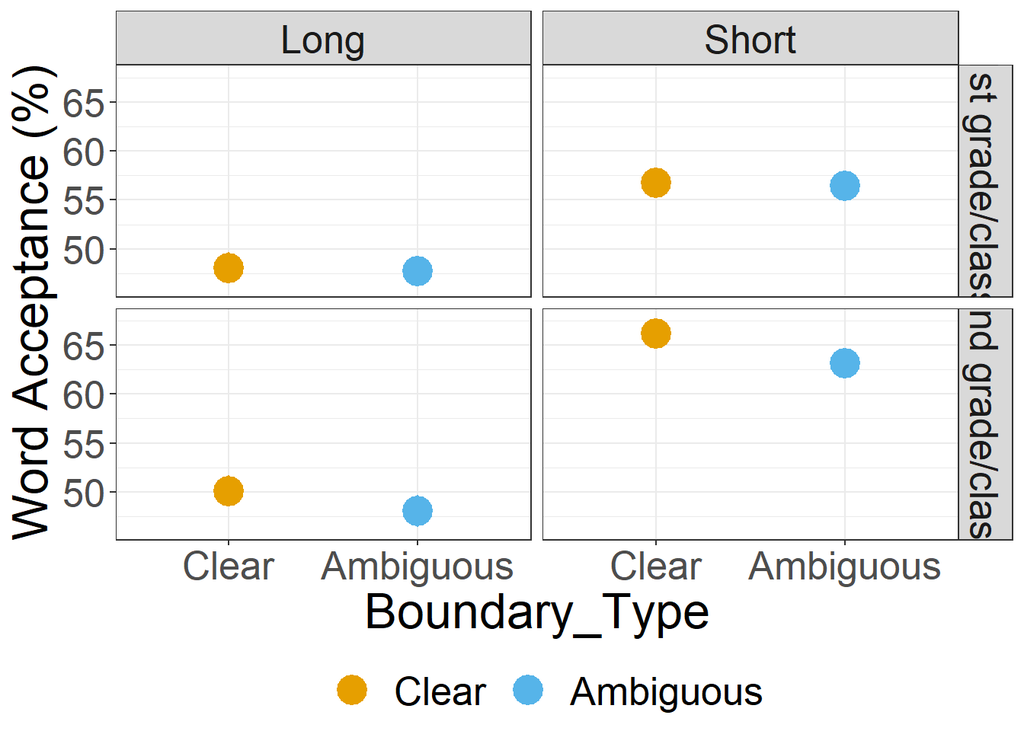

### Age

Approximation for now for L1 knowledge

```
## Generalized linear mixed model fit by maximum likelihood (Laplace
##   Approximation) [glmerMod]
##  Family: binomial  ( logit )
## Formula:
## detection ~ 1 + Word_Candidate_Length * Boundary_Type * DEMO_AgeYears.c +
##     (1 | subject_nr) + (1 | Sentence_Num)
##    Data: Pseg_Htest
## Control: glmerControl(optimizer = "bobyqa")
##
##      AIC      BIC   logLik deviance df.resid
##   9755.2   9824.8  -4867.6   9735.2     7725
##
## Scaled residuals:
##     Min      1Q  Median      3Q     Max
## -4.3319 -0.9028  0.4589  0.7985  3.4613
##
## Random effects:
##  Groups       Name        Variance Std.Dev.
##  Sentence_Num (Intercept) 0.2007   0.4480
##  subject_nr   (Intercept) 0.6864   0.8285
## Number of obs: 7735, groups:  Sentence_Num, 120; subject_nr, 103
##
## Fixed effects:
##                                                        Estimate Std. Error
## (Intercept)                                            0.193535   0.094821
## Word_Candidate_Length1                                -0.581803   0.050104
## Boundary_Type1                                         0.062583   0.049815
## DEMO_AgeYears.c                                        0.152166   0.112174
## Word_Candidate_Length1:Boundary_Type1                  0.006426   0.099641
## Word_Candidate_Length1:DEMO_AgeYears.c                -0.208779   0.065482
## Boundary_Type1:DEMO_AgeYears.c                         0.025223   0.065199
## Word_Candidate_Length1:Boundary_Type1:DEMO_AgeYears.c -0.087167   0.130745
##                                                       z value Pr(>|z|)
## (Intercept)                                             2.041  0.04125 *
## Word_Candidate_Length1                                -11.612  < 2e-16 ***
## Boundary_Type1                                          1.256  0.20901
## DEMO_AgeYears.c                                         1.357  0.17494
## Word_Candidate_Length1:Boundary_Type1                   0.064  0.94858
## Word_Candidate_Length1:DEMO_AgeYears.c                 -3.188  0.00143 **
## Boundary_Type1:DEMO_AgeYears.c                          0.387  0.69886
## Word_Candidate_Length1:Boundary_Type1:DEMO_AgeYears.c  -0.667  0.50497
## ---
## Signif. codes:  0 '***' 0.001 '**' 0.01 '*' 0.05 '.' 0.1 ' ' 1
##
## Correlation of Fixed Effects:
##              (Intr) Wr_C_L1 Bnd_T1 DEMO_A Wr_C_L1:B_T1 W_C_L1:D B_T1:D
## Wrd_Cndd_L1  -0.007
## Bondry_Typ1   0.001 -0.006
## DEMO_AgYrs.   0.006 -0.008   0.001
## Wr_C_L1:B_T1 -0.002  0.005  -0.027 -0.001
## W_C_L1:DEMO  -0.005  0.003  -0.002 -0.008  0.002
## B_T1:DEMO_A   0.001 -0.001  -0.004  0.001 -0.021       -0.012
## W_C_L1:B_T1: -0.001  0.005  -0.016 -0.003 -0.004        0.004   -0.028
```

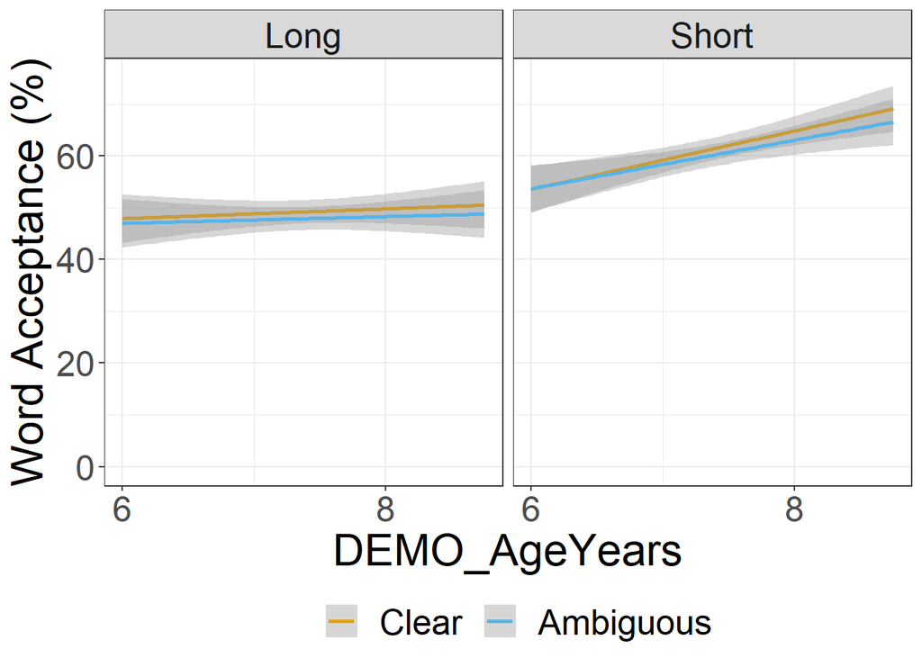